# Luftdruck und Firntemperatur

Doppelkette GRIP (IMEI 301434062008130) — Messung, Theorie und die Unruhe im offenen Bohrloch

Author

Thom Laepple

Published

September 24, 2026

Die Doppelkette misst in zwei Bohrlöchern 10 m voneinander: **Kette 1 im offenen, luftgefüllten Loch, Kette 2 im mit Schnee verfüllten**, beide mit Knoten bei 1/3/5/8/10/13/16/21/26/30 m und je einem Druck- und zwei NTC-Kanälen. Ein Profil pro Tag. Der Bohrloch-Vergleich steht in `decode_chain.qmd`; hier geht es um den Zusammenhang von Luftdruck und Temperatur.

```r
source("decode_core.R")
library(dplyr); library(tidyr); library(ggplot2); library(patchwork)

BIN <- setdiff(Sys.glob("../testdata/301434062008130-*.bin"),
               "../testdata/301434062008130-138.bin")
FIELDS <- c("ntc1", "ntc2", "gnd", "pressure"); N_NODES <- 20L
lab_cal <- load_lab_cal(NA_character_, N_NODES)

depth_map <- rbind(
  data.frame(position = 1:10,  chain = "Kette 1 — Luft",   depth_m = c(1,3,5,8,10,13,16,21,26,30)),
  data.frame(position = 11:20, chain = "Kette 2 — Schnee", depth_m = c(1,3,5,8,10,13,16,21,26,30)))

series <- bind_rows(lapply(BIN, function(f) {
  b  <- read_snowchain_bin(f, FIELDS, N_NODES)
  nd <- bin_to_nodes(b, FIELDS, lab_cal); nd$position <- nd$node
  merge(nd, depth_map, by = "position") |> mutate(time = unix2utc(b$time_unix)) })) |>
  mutate(ntc_C = rowMeans(cbind(ntc1_C, ntc2_C), na.rm = TRUE)) |>
  filter(time > as.POSIXct("2026-07-10", tz = "UTC"))   # nach dem Einbau

WINDOW <- 45                                            # Auswertefenster in Tagen
t_end  <- max(series$time)
win    <- series |> filter(time >= t_end - WINDOW * 86400, !is.na(ntc_C))

# Barometrisches Signal = Mittel aller 20 Drucksensoren
bar <- win |> group_by(time) |> summarise(p_bar = mean(pressure_hPa, na.rm = TRUE), .groups = "drop")
win <- win |> left_join(bar, by = "time")

chain_cols <- c("Kette 1 — Luft" = "#e67e22", "Kette 2 — Schnee" = "#2980b9")
```

Ausgewertet werden die letzten 45 Tage (09.08. bis 23.09.2026, 46 Profile).

## Das Drucksignal

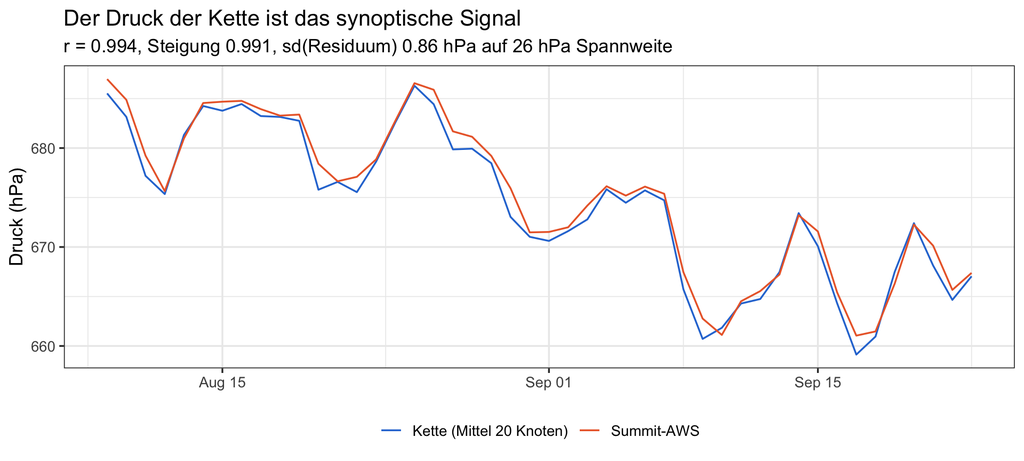

```r
aws <- tryCatch({ options(timeout = 60)
  suppressWarnings(readr::read_csv(
    "https://thredds.geus.dk/thredds/fileServer/aws/l3sites/csv/day/SUM_day.csv",
    show_col_types = FALSE)) |> mutate(day = as.Date(time)) |> select(day, p_aws = p_u) },
  error = function(e) NULL)

pc <- bar |> mutate(day = as.Date(time))
if (!is.null(aws)) pc <- pc |> left_join(aws, by = "day") |> filter(is.finite(p_aws))

if (!is.null(aws)) {
  fit_p <- lm(p_bar ~ p_aws, pc)
  ggplot(pc, aes(day)) +
    geom_line(aes(y = p_bar,  colour = "Kette (Mittel 20 Knoten)"), linewidth = 0.6) +
    geom_line(aes(y = p_aws,  colour = "Summit-AWS"), linewidth = 0.6) +
    scale_colour_manual(values = c("Kette (Mittel 20 Knoten)" = "#2a78d6",
                                   "Summit-AWS" = "#eb6834"), name = NULL) +
    labs(title = "Der Druck der Kette ist das synoptische Signal", x = NULL, y = "Druck (hPa)",
         subtitle = sprintf("r = %.3f, Steigung %.3f, sd(Residuum) %.2f hPa auf %.0f hPa Spannweite",
                            cor(pc$p_bar, pc$p_aws), coef(fit_p)[2], sd(resid(fit_p)),
                            diff(range(pc$p_aws)))) +
    theme_bw(base_size = 13) + theme(legend.position = "bottom")
}
```

Das Barometer der Summit-AWS liegt rund 30 km entfernt und hat eigene Elektronik. Dass die Kette ihm über den vollen Bereich folgt, macht es zur unabhängigen Referenz für alles Folgende.

## Die Temperatur folgt dem Druck — im verfüllten Loch

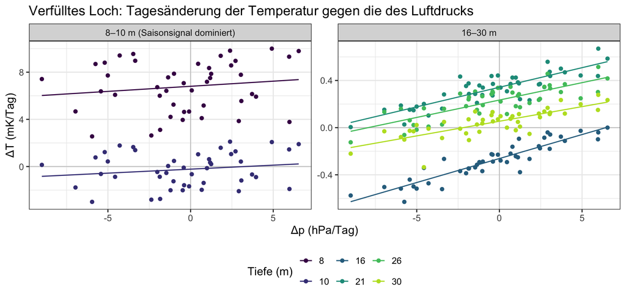

```r
dif <- win |> arrange(chain, depth_m, time) |> group_by(chain, depth_m) |>
  mutate(dT = (ntc_C - lag(ntc_C)) * 1000, dp = p_bar - lag(p_bar),
         drep = (ntc1_C - ntc2_C - lag(ntc1_C - ntc2_C)) * 1000) |>
  ungroup() |> filter(!is.na(dT), !is.na(dp))

dif |> filter(chain == "Kette 2 — Schnee", depth_m >= 8) |>
  mutate(band = factor(ifelse(depth_m <= 10, "8–10 m (Saisonsignal dominiert)", "16–30 m"),
                       c("8–10 m (Saisonsignal dominiert)", "16–30 m")),
         tiefe = factor(depth_m)) |>
  ggplot(aes(dp, dT, colour = tiefe)) +
  geom_hline(yintercept = 0, colour = "grey80") + geom_vline(xintercept = 0, colour = "grey80") +
  geom_point(size = 1.7) + geom_smooth(method = "lm", se = FALSE, linewidth = 0.6) +
  scale_colour_viridis_d(name = "Tiefe (m)", option = "D", end = 0.9) +
  facet_wrap(~ band, scales = "free_y") +
  labs(title = "Verfülltes Loch: Tagesänderung der Temperatur gegen die des Luftdrucks",
       x = "Δp (hPa/Tag)", y = "ΔT (mK/Tag)") +
  theme_bw(base_size = 13) + theme(legend.position = "bottom")
```

Bei 8 und 10 m trägt das eindringende Saisonsignal die Tagesänderung und überdeckt den Druckanteil. Ab 16 m dreht das Verhältnis.

Werden **beide** Reihen gleich gefiltert (loess-Residuum von T und p), ergibt sich das synoptische Band mit Steigung, erklärter Varianz und Lag-Struktur.

```r
band <- bind_rows(lapply(split(win |> filter(depth_m >= 8), ~ chain + depth_m, drop = TRUE),
  function(x) {
    x <- x[order(x$time), ]; if (nrow(x) < 20) return(NULL)
    td <- as.numeric(difftime(x$time, min(x$time), units = "days"))
    rT <- resid(loess(x$ntc_C ~ td, span = 0.5)) * 1000
    rP <- resid(loess(x$p_bar ~ td, span = 0.5))
    f  <- summary(lm(rT ~ rP))
    lg <- sapply(-2:2, function(L) { n <- length(rT); i <- max(1, 1 - L):min(n, n - L)
                                     cor(rT[i], rP[i + L]) })
    r1   <- acf(rP, plot = FALSE, lag.max = 1)$acf[2]
    neff <- length(rP) * (1 - r1) / (1 + r1)          # effektive Freiheitsgrade
    data.frame(chain = x$chain[1], depth_m = x$depth_m[1], sd_T = sd(rT),
               b = f$coefficients[2, 1], se = f$coefficients[2, 2],
               se_ac = f$coefficients[2, 2] * sqrt(length(rP) / neff), n_eff = neff,
               t = f$coefficients[2, 3], r2 = f$r.squared,
               lag_m1 = lg[2], lag_0 = lg[3], lag_p1 = lg[4]) }))

knitr::kable(band |> transmute(Kette = chain, `Tiefe (m)` = depth_m,
    `b (mK/hPa)` = round(b, 3), `t` = round(t, 1), `R²` = round(r2, 2),
    `r −1 Tag` = round(lag_m1, 2), `r 0` = round(lag_0, 2), `r +1 Tag` = round(lag_p1, 2)),
  caption = "Gleich gefilterte Reihen. Im verfüllten Loch phasengleich und hochsignifikant, im offenen Loch nicht nachweisbar.")
```

Gleich gefilterte Reihen. Im verfüllten Loch phasengleich und hochsignifikant, im offenen Loch nicht nachweisbar.

| Kette | Tiefe (m) | b (mK/hPa) | t | R² | r −1 Tag | r 0 | r +1 Tag |
| --- | --- | --- | --- | --- | --- | --- | --- |
| Kette 1 — Luft | 8 | -0.234 | -0.3 | 0.00 | -0.48 | -0.04 | 0.41 |
| Kette 2 — Schnee | 8 | 0.067 | 16.6 | 0.86 | 0.70 | 0.93 | 0.40 |
| Kette 1 — Luft | 10 | 0.056 | 0.2 | 0.00 | -0.48 | 0.03 | 0.51 |
| Kette 2 — Schnee | 10 | 0.055 | 15.2 | 0.84 | 0.69 | 0.92 | 0.41 |
| Kette 1 — Luft | 13 | 0.219 | 0.6 | 0.01 | -0.49 | 0.10 | 0.53 |
| Kette 1 — Luft | 16 | 0.158 | 0.2 | 0.00 | -0.48 | 0.02 | 0.42 |
| Kette 2 — Schnee | 16 | 0.043 | 26.6 | 0.94 | 0.62 | 0.97 | 0.53 |
| Kette 1 — Luft | 21 | -0.053 | -0.1 | 0.00 | -0.49 | -0.01 | 0.40 |
| Kette 2 — Schnee | 21 | 0.033 | 21.1 | 0.91 | 0.57 | 0.95 | 0.50 |
| Kette 1 — Luft | 26 | -0.004 | 0.0 | 0.00 | -0.49 | 0.00 | 0.42 |
| Kette 2 — Schnee | 26 | 0.029 | 20.3 | 0.90 | 0.52 | 0.95 | 0.55 |
| Kette 1 — Luft | 30 | 0.018 | 0.1 | 0.00 | -0.48 | 0.02 | 0.45 |
| Kette 2 — Schnee | 30 | 0.023 | 11.4 | 0.75 | 0.56 | 0.86 | 0.37 |

Im verfüllten Loch erklärt der Luftdruck **75–94 %** der synoptischen Temperaturvarianz, phasengleich (Maximum bei Lag 0) und ohne freien Parameter erklärbar. Zwei Kontrollen schließen Elektronik aus:

```r
ctrl <- dif |> filter(depth_m >= 16) |> group_by(chain, depth_m) |>
  summarise(`r(NTC1−NTC2, Δp)` = round(cor(drep, dp), 2), .groups = "drop")

aws_ctrl <- if (!is.null(aws)) {
  dif |> mutate(day = as.Date(time)) |> left_join(aws, by = "day") |>
    arrange(chain, depth_m, time) |> group_by(chain, depth_m) |>
    mutate(dp_aws = p_aws - lag(p_aws)) |> filter(depth_m >= 16, !is.na(dp_aws)) |>
    summarise(`b mit AWS-Barometer (mK/hPa)` = round(coef(lm(dT ~ dp_aws))[2], 3),
              `t (AWS)` = round(summary(lm(dT ~ dp_aws))$coefficients[2, 3], 1), .groups = "drop")
} else NULL

knitr::kable(if (is.null(aws_ctrl)) ctrl else left_join(ctrl, aws_ctrl, by = c("chain", "depth_m")) |>
               rename(Kette = chain, `Tiefe (m)` = depth_m),
  caption = "Kontrollen: Replikat-Differenz gegen Δp (kanalspezifischer Effekt) und Regression gegen ein fremdes Barometer (Temperaturkompensation der eigenen Drucksensoren).")
```

Kontrollen: Replikat-Differenz gegen Δp (kanalspezifischer Effekt) und Regression gegen ein fremdes Barometer (Temperaturkompensation der eigenen Drucksensoren).

| Kette | Tiefe (m) | r(NTC1−NTC2, Δp) | b mit AWS-Barometer (mK/hPa) | t (AWS) |
| --- | --- | --- | --- | --- |
| Kette 1 — Luft | 16 | -0.07 | -1.660 | -1.0 |
| Kette 1 — Luft | 21 | -0.08 | -1.384 | -1.2 |
| Kette 1 — Luft | 26 | -0.07 | -0.615 | -1.1 |
| Kette 1 — Luft | 30 | -0.08 | -0.236 | -1.1 |
| Kette 2 — Schnee | 16 | -0.06 | 0.043 | 13.5 |
| Kette 2 — Schnee | 21 | 0.23 | 0.035 | 9.2 |
| Kette 2 — Schnee | 26 | 0.03 | 0.030 | 7.5 |
| Kette 2 — Schnee | 30 | 0.04 | 0.028 | 8.7 |

Die Replikat-Differenz NTC1−NTC2 desselben Knotens folgt dem Druck nicht — beide Kanäle bewegen sich gemeinsam. Und mit dem Barometer der Summit-AWS kommen dieselben Steigungen heraus; ein Kompensationsfehler der eigenen Drucksensoren kann sich dort nicht abbilden.

## Das Modell

### Schritt 1 in Worten

Firn besteht aus Eis und Luft. Eis lässt sich nicht komprimieren, Luft schon — auf eine Druckänderung reagiert also nur die Luft in den Poren.

Die Pore ist dabei **nicht** abgeschlossen: sie hängt über die durchlässige Firnsäule an der Atmosphäre. Das Bild ist deshalb nicht die Luftpumpe, sondern das **Befüllen einer starren Flasche**. Steigt der Außendruck, drückt die Atmosphäre zusätzliche Luft in ein Volumen, das sich nicht ändert — und eine Druckluftflasche wird beim Befüllen warm, obwohl niemand einen Kolben bewegt.

Woher die Wärme kommt: um Luft in die Pore zu schieben, muss die Atmosphäre sie gegen den herrschenden Druck verdrängen. Diese **Verdrängungsarbeit** kommt mit der einströmenden Luft mit. Gespeichert wird davon nur der Teil, der der inneren Energie des zusätzlichen Gases entspricht; der Rest wird frei. Bei einem idealen Gas ist die Differenz gerade `R_s·T` je Kilogramm — und über `ρ_L R_s T = p` wird daraus **Wärme = Porenvolumen × Druckanstieg**.

In Zahlen: ein Kubikmeter Firn mit 50 % Porenanteil, Druckanstieg 10 hPa = 1000 Pa → 0,5 m³ · 1000 Pa = **500 Joule**. (Pascal mal Kubikmeter ist Joule; die Formel ist am Ende diese Einheitenrechnung.)

**Wo die Wärme bleibt.** Nicht in der Luft — die Poren sind mikroskopisch klein, die Oberfläche riesig, die Luft gibt ihre Wärme in Millisekunden ans Eis ab und bleibt auf Eistemperatur. Ein Kubikmeter Firn wiegt 450 kg, Eis braucht 1780 J je Kilogramm und Kelvin, macht 800 000 J/K. Die 500 Joule heben die Temperatur also um 500/800 000 = **0,62 mK**.

Dieselbe Zahl von der anderen Seite: bliebe die Wärme in der Luft, würde diese sich bei 10 hPa um rund **1 K** erwärmen. Sie teilt sie aber mit dem Eis, dessen Wärmekapazität je Volumen 1640-mal größer ist. Von 1 K bleiben 1 K/1640 = **0,6 mK**.

Und es gilt in beide Richtungen: fällt der Druck, strömt Luft aus, die Verdrängungsarbeit wird zurückgefordert, das Eis kühlt um denselben Betrag ab. Deshalb ist das Signal phasengleich mit dem Druck und in beiden Vorzeichen symmetrisch — so, wie es gemessen wird.

Ein Nebenpunkt, der oft die erste Rückfrage ist: die einströmende Luft kommt aus der Schicht darüber und bringt deren Temperatur mit. Dieser Advektionsanteil ist vernachlässigbar, weil die Wärmekapazität der bewegten Luft nur 5·10⁻⁴ der Matrix beträgt — rechnerisch 0,001 bis 0,002 mK/hPa gegen die 0,03 bis 0,09 mK/hPa der Kompressionswärme.

### Schritt 1 — die Herleitung

Betrachtet wird ein Einheitsvolumen Firn in der Tiefe z mit **offener** Porosität φ. Das Porenvolumen ist starr, die Temperatur konstant (die Matrix hält sie), der Kontrollraum offen gegen die Atmosphäre. Steigt der Luftdruck um Δp, strömt Masse nach: die einströmende Masse `dm = φ ρ_L Δp/p` bringt die Enthalpie `c_p T dm` mit, die innere Energie des Porengases wächst nur um `c_v T dm`. Die Differenz geht als Wärme an die Matrix:

$$\mathrm{d}Q \;=\; (c_p - c_v)\,T\,\mathrm{d}m \;=\; R_s\,T\,\varphi\,\rho_L\,\frac{\Delta p}{p} \;=\; \varphi\,\Delta p .$$

Der letzte Schritt nutzt `ρ_L R_s T = p`. Das Ergebnis hängt weder von der Temperatur noch von den Stoffwerten der Luft ab: **pro Volumen wird die Wärme φ·Δp frei.** Bei φ = 0,5 und Δp = 10 hPa sind das 500 J/m³.

### Schritt 2 — Wohin die Wärme geht

Aufgenommen wird sie von der Eismatrix. Deren Wärmekapazität je Volumen ist `ρ_Firn · c_Eis` ≈ 450 · 1780 = 8·10⁵ J/(m³·K); die Porenluft selbst trägt mit `φ ρ_L c_p` ≈ 500 J/(m³·K) nur 0,06 % bei und ist zu vernachlässigen. Damit

$$\boxed{\;b(z) \;=\; \frac{\Delta T}{\Delta p} \;=\; \frac{\varphi(z)}{\rho_{\mathrm{Firn}}(z)\; c_{\mathrm{Eis}}}\;}$$

Für das Beispiel: 500 J/m³ / 8·10⁵ J/(m³K) = 0,62 mK auf 10 hPa, also 0,062 mK/hPa.

### Schritt 3 — Warum die Wärme lokal bleibt

`φ = 1 − ρ/917` macht b zu einer reinen Funktion der Dichte. Das Dichteprofil kommt aus **Herron & Langway (1980)**, mit der Jahresmitteltemperatur und der Akkumulation des Standorts als einzigen Eingaben:

- Stadium 1 (ρ < 550 kg/m³): `k₀ = 11 exp(−10160/RT)`, `ln(ρ/(ρ_i−ρ)) = ρ_i k₀ z + const`
- Stadium 2 (ρ > 550): `k₁ = 575 exp(−21400/RT)`, mit der Akkumulation als `1/√A`
- Wärmekapazität des Eises temperaturabhängig: `c(T) = 152,5 + 7,122·T[K]`, also 1781 J/(kg·K) bei −44,5 °C und 1876 bei −31 °C

### Ist das Porenvolumen aus der Dichte exakt?

`φ = 1 − ρ/ρ_Eis` liefert die **Gesamt**porosität. Der Effekt sieht aber nur die **offene**, also die mit der Atmosphäre verbundene. Zwei Korrekturen trennen die beiden, und beide sind oben klein und unten groß.

```r
Tk5 <- 228.6; TC5 <- Tk5 - 273.15
rho_ice_T <- 917 * (1 + 1.53e-4 * (-TC5))                 # thermische Ausdehnung des Eises
rco  <- 1/(1/0.917 + 6.95e-4*Tk5 - 0.043) * 1000          # Close-off-Dichte, Martinerie et al. 1992
phico <- 1 - rco/rho_ice_T
dK5 <- local({ k0 <- 11*exp(-10160/(8.314*Tk5)); k1 <- 575*exp(-21400/(8.314*Tk5))
  z55 <- (log(.55/(.917-.55)) - log(.34/(.917-.34)))/(.917*k0)
  function(z) vapply(z, function(q) { Z <- if (q <= z55) exp(.917*k0*q + log(.34/(.917-.34)))
    else exp(.917*k1*(q - z55)/sqrt(0.064) + log(.55/(.917-.55))); .917*Z/(1+Z) }, 0) })

po <- bind_rows(lapply(c(5, 10, 30, 50, 70, 80, 84), function(z) {
  r <- dK5(z)*1000; p917 <- 1 - r/917; pT <- 1 - r/rho_ice_T
  fcl <- if (pT > phico) min(1, 0.37*(pT/phico)^(-7.6)) else 1
  data.frame(`Tiefe (m)` = z, `ρ (kg/m³)` = round(r),
             `φ mit 917` = round(p917, 4), `φ mit ρ_Eis(T)` = round(pT, 4),
             `geschlossen (%)` = round(100*fcl, 1), `φ_offen` = round(pT*(1-fcl), 4),
             `φ_offen / φ(917)` = round(pT*(1-fcl)/p917, 3), check.names = FALSE) }))
knitr::kable(po, row.names = FALSE,
  caption = sprintf("Kohnen: Eisdichte %.0f kg/m³ statt 917 (thermische Ausdehnung bei %.1f °C), Close-off bei %.0f kg/m³ (φ_co = %.3f), geschlossener Anteil nach Goujon et al. (2003).",
                    rho_ice_T, TC5, rco, phico))
```

Kohnen: Eisdichte 923 kg/m³ statt 917 (thermische Ausdehnung bei -44.5 °C), Close-off bei 829 kg/m³ (φ_co = 0.102), geschlossener Anteil nach Goujon et al. (2003).

| Tiefe (m) | ρ (kg/m³) | φ mit 917 | φ mit ρ_Eis(T) | geschlossen (%) | φ_offen | φ_offen / φ(917) |
| --- | --- | --- | --- | --- | --- | --- |
| 5 | 393 | 0.5716 | 0.5745 | 0.0 | 0.5745 | 1.005 |
| 10 | 448 | 0.5120 | 0.5153 | 0.0 | 0.5153 | 1.006 |
| 30 | 610 | 0.3343 | 0.3388 | 0.0 | 0.3388 | 1.013 |
| 50 | 709 | 0.2269 | 0.2321 | 0.1 | 0.2320 | 1.022 |
| 70 | 783 | 0.1464 | 0.1522 | 1.8 | 0.1495 | 1.021 |
| 80 | 811 | 0.1159 | 0.1219 | 9.7 | 0.1102 | 0.950 |
| 84 | 820 | 0.1054 | 0.1114 | 19.1 | 0.0901 | 0.855 |

### Kürzt sich γ heraus? Ja, exakt

Die Herleitung über den offenen Kontrollraum und die anschauliche über „adiabatische Erwärmung, dann mit der Matrix geteilt” führen nicht nur ungefähr, sondern **identisch** zum selben Ergebnis. Der zweite Weg:

$$\Delta T_{\mathrm{Luft}} = \frac{R_s}{c_p}\,T\,\frac{\Delta p}{p},
\qquad
\Delta T = \Delta T_{\mathrm{Luft}}\cdot\frac{\varphi\rho_L c_p}{\rho_f c_i}
= \frac{\varphi\,\rho_L R_s T}{p}\cdot\frac{\Delta p}{\rho_f c_i}
= \frac{\varphi\,\Delta p}{\rho_f c_i}.$$

Im vorletzten Schritt kürzt sich `c_p` heraus, im letzten `ρ_L R_s T = p`. Es bleibt **kein** Faktor γ oder `c_p/c_v` übrig — die Wärmekapazität und die Adiabatenexponenten der Luft fallen vollständig heraus. Zahlenprobe: mit φ = 0,564, ρ_f = 400 kg/m³, c_i = 1900 J/(kg·K) geben beide Wege 564 J/m³ und damit `b = 7,42·10⁻⁷ K/Pa = 0,074 mK/hPa`, also 0,74 mK auf 10 hPa. Frühere Überschlagswerte um 0,5 mK/10 hPa unterscheiden sich nur durch andere φ, ρ und c, nicht durch den Weg.

### Was Messung und Theorie trennt: die Ausbreitung der Druckstörung

`b = φ/(ρ c)` ist der **thermodynamische** Koeffizient. Gemessen wird die Steigung gegen den Druck **an der Oberfläche**, und dazwischen liegt die Firnsäule. Die Störung breitet sich diffusiv aus, `D_p = k p/(φ μ)`, mit der Eindringtiefe `δ = √(2 D_p/ω)`; gemessen wird deshalb

$$b_{\mathrm{gemessen}}(z) = \frac{\varphi(z)}{\rho(z) c}\cdot e^{-z/\delta},
\qquad \text{mit Phasenverzug } \frac{z}{\delta\,\omega}.$$

```r
mu <- 1.7e-5; p_s <- 65000; Tper <- 3 * 86400; om_p <- 2*pi/Tper
ausb <- bind_rows(lapply(c(1e-8, 1e-9, 1e-10, 1e-11), function(k) {
  phi_l <- 0.3; Dp <- k * p_s/(phi_l * mu); del <- sqrt(2*Dp/om_p)
  data.frame(`Permeabilität (m²)` = sprintf("%.0e", k),
             `D_p (m²/s)` = signif(Dp, 3), `Eindringtiefe (m)` = round(del),
             `Amplitude 30 m` = sprintf("%.0f %%", 100*exp(-30/del)),
             `Verzug 30 m` = sprintf("%.0f min", (30/del)/om_p/60),
             `Amplitude 80 m` = sprintf("%.0f %%", 100*exp(-80/del)),
             `Verzug 80 m` = sprintf("%.0f min", (80/del)/om_p/60), check.names = FALSE) }))
knitr::kable(ausb, row.names = FALSE,
  caption = "Ausbreitung einer synoptischen Druckstörung (3-Tage-Periode) im Firn.")
```

Ausbreitung einer synoptischen Druckstörung (3-Tage-Periode) im Firn.

| Permeabilität (m²) | D_p (m²/s) | Eindringtiefe (m) | Amplitude 30 m | Verzug 30 m | Amplitude 80 m | Verzug 80 m |
| --- | --- | --- | --- | --- | --- | --- |
| 1e-08 | 127.000 | 3243 | 99 % | 6 min | 98 % | 17 min |
| 1e-09 | 12.700 | 1025 | 97 % | 20 min | 92 % | 54 min |
| 1e-10 | 1.270 | 324 | 91 % | 64 min | 78 % | 170 min |
| 1e-11 | 0.127 | 103 | 75 % | 201 min | 46 % | 536 min |

Solange man im oberen Firn bleibt, gilt `b ≈ φ/(ρc)` mit wenigen Prozent Abschlag; die Gleichsetzung ohne Korrektur ist erst dort zulässig, wo die Permeabilität hoch ist.

### Schritt 5 — Der Schätzer

Je Knoten werden Temperatur- und Druckreihe **gleich** hochpassgefiltert (loess-Residuum), so dass nur das synoptische Band übrig bleibt; dann

$$\hat b = \frac{\mathrm{cov}(r_T, r_p)}{\mathrm{var}(r_p)} , \qquad
\mathrm{SE}(\hat b) = \frac{\sigma_T}{\sigma_p \sqrt{N_{\mathrm{eff}}}} , \qquad
N_{\mathrm{eff}} = N\,\frac{1-r_1}{1+r_1} .$$

Die Autokorrelationskorrektur ist nötig, weil der Luftdruck erst nach etwa vier Tagen dekorreliert.

### Was das Modell voraussetzt

[output not shown]

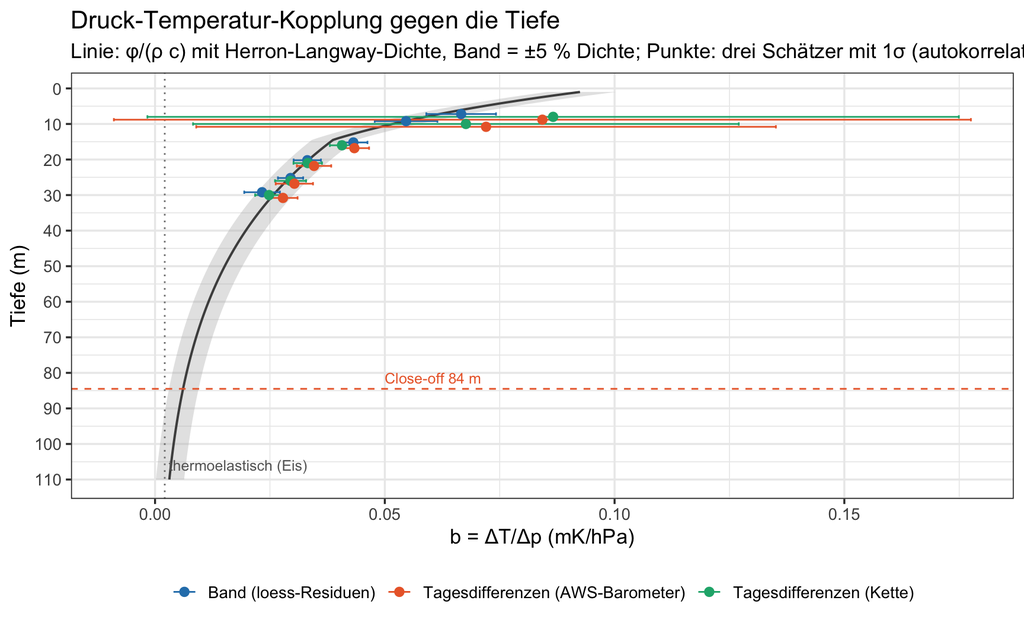

```r
Rg <- 8.314; T_site <- 242; acc <- 0.23; rho_i <- 0.917; rho_0 <- 0.34
c_ice <- 152.5 + 7.122 * T_site       # Alexiades & Solomon: c_Eis(T)
k0 <- 11 * exp(-10160 / (Rg * T_site)); k1 <- 575 * exp(-21400 / (Rg * T_site))
z550 <- (log(0.55 / (rho_i - 0.55)) - log(rho_0 / (rho_i - rho_0))) / (rho_i * k0)
dens <- function(z) vapply(z, function(zz) {
  Z <- if (zz <= z550) exp(rho_i * k0 * zz + log(rho_0 / (rho_i - rho_0)))
       else exp(rho_i * k1 * (zz - z550) / sqrt(acc) + log(0.55 / (rho_i - 0.55)))
  rho_i * Z / (1 + Z) }, 0)
b_theor <- function(z) { r <- dens(z) * 1000; (1 - r / 917) / (r * c_ice) * 1e5 }
z_co  <- uniroot(function(z) dens(z) - 0.83, c(1, 200))$root
b_ice <- 1.5e-4 * T_site / (917 * c_ice) * 1e5

# Drei Schätzer derselben Größe: gleich gefiltertes Band, Tagesdifferenzen gegen den
# Kettendruck und gegen das AWS-Barometer. Fehlerbalken autokorrelations-korrigiert.
est_band <- band |> filter(chain == "Kette 2 — Schnee") |>
  transmute(z = depth_m, b, se = se_ac, quelle = "Band (loess-Residuen)")

est_diff <- dif |> filter(chain == "Kette 2 — Schnee", depth_m >= 8) |>
  group_by(depth_m) |> summarise(b = coef(lm(dT ~ dp))[2],
    se = summary(lm(dT ~ dp))$coefficients[2, 2], .groups = "drop") |>
  transmute(z = depth_m, b, se, quelle = "Tagesdifferenzen (Kette)")

est_aws <- if (!is.null(aws)) {
  dif |> mutate(day = as.Date(time)) |> left_join(aws, by = "day") |>
    arrange(chain, depth_m, time) |> group_by(chain, depth_m) |>
    mutate(dp_aws = p_aws - lag(p_aws)) |> ungroup() |>
    filter(chain == "Kette 2 — Schnee", depth_m >= 8, !is.na(dp_aws)) |>
    group_by(depth_m) |> summarise(b = coef(lm(dT ~ dp_aws))[2],
      se = summary(lm(dT ~ dp_aws))$coefficients[2, 2], .groups = "drop") |>
    transmute(z = depth_m, b, se, quelle = "Tagesdifferenzen (AWS-Barometer)")
} else NULL

est <- bind_rows(est_band, est_diff, est_aws) |>
  mutate(z_off = z + c("Band (loess-Residuen)" = -0.8, "Tagesdifferenzen (Kette)" = 0,
                       "Tagesdifferenzen (AWS-Barometer)" = 0.8)[quelle])

# Theorieband: ±5 % Unsicherheit im modellierten Dichteprofil
theo <- data.frame(z = seq(1, 110, 0.5)) |>
  mutate(b = b_theor(z),
         lo = (1 - dens(z) * 1050 / 917) / (dens(z) * 1050 * c_ice) * 1e5,
         hi = (1 - dens(z) *  950 / 917) / (dens(z) *  950 * c_ice) * 1e5)

ggplot(theo, aes(b, z)) +
  geom_ribbon(aes(xmin = lo, xmax = hi, y = z), fill = "grey70", alpha = 0.35, inherit.aes = FALSE) +
  geom_line(linewidth = 0.7, colour = "grey30") +
  geom_vline(xintercept = b_ice, linetype = "dotted", colour = "grey50") +
  geom_hline(yintercept = z_co, linetype = "dashed", colour = "#eb6834") +
  geom_errorbarh(data = est, aes(y = z_off, xmin = b - se, xmax = b + se, colour = quelle),
                 height = 0.9, linewidth = 0.5, inherit.aes = FALSE) +
  geom_point(data = est, aes(b, z_off, colour = quelle), size = 2.4, inherit.aes = FALSE) +
  annotate("text", x = b_ice, y = 106, label = " thermoelastisch (Eis)", hjust = 0,
           size = 3.3, colour = "grey40") +
  annotate("text", x = 0.05, y = z_co - 3, label = sprintf("Close-off %.0f m", z_co),
           hjust = 0, size = 3.3, colour = "#eb6834") +
  scale_colour_manual(values = c("Band (loess-Residuen)" = "#2980b9",
                                 "Tagesdifferenzen (Kette)" = "#1baf7a",
                                 "Tagesdifferenzen (AWS-Barometer)" = "#eb6834"), name = NULL) +
  scale_y_reverse(name = "Tiefe (m)", breaks = seq(0, 110, 10)) +
  scale_x_continuous(name = "b = ΔT/Δp (mK/hPa)") +
  labs(title = "Druck-Temperatur-Kopplung gegen die Tiefe",
       subtitle = "Linie: φ/(ρ c) mit Herron-Langway-Dichte, Band = ±5 % Dichte; Punkte: drei Schätzer mit 1σ (autokorrelations-korrigiert)") +
  theme_bw(base_size = 13) + theme(legend.position = "bottom")
```

```r
obs <- est_band |> select(z, b)
```

```r
knitr::kable(bind_rows(
  obs |> transmute(`Tiefe (m)` = z, `b gemessen (mK/hPa)` = round(b, 4),
                   `ρ (kg/m³)` = round(dens(z) * 1000, 0),
                   `φ` = round(1 - dens(z) * 1000 / 917, 3),
                   `b = φ/(ρc)` = round(b_theor(z), 4),
                   `Verhältnis` = round(b / b_theor(z), 2)),
  data.frame(`Tiefe (m)` = c(50, 70, round(z_co)), `b gemessen (mK/hPa)` = NA,
             `ρ (kg/m³)` = round(dens(c(50, 70, z_co)) * 1000, 0),
             `φ` = round(1 - dens(c(50, 70, z_co)) * 1000 / 917, 3),
             `b = φ/(ρc)` = round(b_theor(c(50, 70, z_co)), 4),
             `Verhältnis` = NA, check.names = FALSE)),
  caption = sprintf("Messung gegen Vorhersage. Unterhalb des Close-off (%.0f m) bleibt die thermoelastische Antwort des Eises, %.4f mK/hPa.", z_co, b_ice))
```

Messung gegen Vorhersage. Unterhalb des Close-off (84 m) bleibt die thermoelastische Antwort des Eises, 0.0021 mK/hPa.

| Tiefe (m) | b gemessen (mK/hPa) | ρ (kg/m³) | φ | b = φ/(ρc) | Verhältnis |
| --- | --- | --- | --- | --- | --- |
| 8 | 0.0666 | 456 | 0.503 | 0.0588 | 1.13 |
| 10 | 0.0546 | 485 | 0.471 | 0.0517 | 1.06 |
| 16 | 0.0432 | 559 | 0.390 | 0.0372 | 1.16 |
| 21 | 0.0331 | 587 | 0.359 | 0.0326 | 1.02 |
| 26 | 0.0295 | 615 | 0.330 | 0.0286 | 1.03 |
| 30 | 0.0233 | 636 | 0.307 | 0.0257 | 0.91 |
| 50 | NA | 727 | 0.207 | 0.0152 | NA |
| 70 | NA | 795 | 0.133 | 0.0089 | NA |
| 84 | NA | 830 | 0.095 | 0.0061 | NA |

```r
knitr::kable(
  est |> select(-z_off) |> mutate(b = round(b, 4), se = round(se, 4)) |>
    tidyr::pivot_wider(names_from = quelle, values_from = c(b, se)) |> arrange(z) |>
    rename(`Tiefe (m)` = z),
  caption = "Drei Schätzer derselben Größe mit Standardfehler. Die effektive Stichprobe ist wegen der ~4-tägigen Dekorrelation des Luftdrucks nur rund ein Viertel der Tage.")
```

Drei Schätzer derselben Größe mit Standardfehler. Die effektive Stichprobe ist wegen der ~4-tägigen Dekorrelation des Luftdrucks nur rund ein Viertel der Tage.

| Tiefe (m) | b_Band (loess-Residuen) | b_Tagesdifferenzen (Kette) | b_Tagesdifferenzen (AWS-Barometer) | se_Band (loess-Residuen) | se_Tagesdifferenzen (Kette) | se_Tagesdifferenzen (AWS-Barometer) |
| --- | --- | --- | --- | --- | --- | --- |
| 8 | 0.0666 | 0.0866 | 0.0843 | 0.0076 | 0.0883 | 0.0933 |
| 10 | 0.0546 | 0.0676 | 0.0720 | 0.0068 | 0.0594 | 0.0631 |
| 16 | 0.0432 | 0.0407 | 0.0434 | 0.0031 | 0.0026 | 0.0032 |
| 21 | 0.0331 | 0.0332 | 0.0346 | 0.0030 | 0.0031 | 0.0037 |
| 26 | 0.0295 | 0.0295 | 0.0303 | 0.0027 | 0.0034 | 0.0041 |
| 30 | 0.0233 | 0.0248 | 0.0278 | 0.0039 | 0.0030 | 0.0032 |

```r
trend <- bind_rows(lapply(split(est, est$quelle), function(g)
  data.frame(Schätzer = g$quelle[1],
             steigung = coef(lm(b ~ z, data = g, weights = 1 / g$se^2))[2],
             se = summary(lm(b ~ z, data = g, weights = 1 / g$se^2))$coefficients[2, 2])))
theo_tr <- coef(lm(b_theor(c(16, 21, 26, 30)) ~ c(16, 21, 26, 30)))[2]

wmean <- est |> group_by(z) |> summarise(
  b = sum(b / se^2) / sum(1 / se^2), se = sqrt(1 / sum(1 / se^2)), .groups = "drop") |>
  mutate(theorie = b_theor(z), sigma = (b - theorie) / se)

knitr::kable(bind_rows(
  trend |> transmute(Zeile = Schätzer, `Wert` = sprintf("%+.5f ± %.5f mK/hPa je m", steigung, se),
                     `Signifikanz` = sprintf("%.1f σ", abs(steigung / se))),
  data.frame(Zeile = "Theorie φ/(ρc)", Wert = sprintf("%+.5f mK/hPa je m", theo_tr),
             Signifikanz = "—")), row.names = FALSE,
  caption = "Tiefentrend von b über 16–30 m, je Schätzer gewichtet gefittet.")
```

Tiefentrend von b über 16–30 m, je Schätzer gewichtet gefittet.

| Zeile | Wert | Signifikanz |
| --- | --- | --- |
| Band (loess-Residuen) | -0.00160 ± 0.00022 mK/hPa je m | 7.4 σ |
| Tagesdifferenzen (AWS-Barometer) | -0.00111 ± 0.00014 mK/hPa je m | 7.7 σ |
| Tagesdifferenzen (Kette) | -0.00112 ± 0.00010 mK/hPa je m | 11.0 σ |
| Theorie φ/(ρc) | -0.00082 mK/hPa je m | — |

```r
knitr::kable(wmean |> transmute(`Tiefe (m)` = z, `b gewichtet (mK/hPa)` = round(b, 4),
    `± (mK/hPa)` = round(se, 4), `Theorie` = round(theorie, 4),
    `Abweichung (σ)` = round(sigma, 1)),
  caption = "Gewichtetes Mittel der drei Schätzer gegen die Vorhersage.")
```

Gewichtetes Mittel der drei Schätzer gegen die Vorhersage.

| Tiefe (m) | b gewichtet (mK/hPa) | ± (mK/hPa) | Theorie | Abweichung (σ) |
| --- | --- | --- | --- | --- |
| 8 | 0.0669 | 0.0075 | 0.0588 | 1.1 |
| 10 | 0.0550 | 0.0067 | 0.0517 | 0.5 |
| 16 | 0.0422 | 0.0017 | 0.0372 | 2.9 |
| 21 | 0.0335 | 0.0019 | 0.0326 | 0.5 |
| 26 | 0.0297 | 0.0019 | 0.0286 | 0.6 |
| 30 | 0.0255 | 0.0019 | 0.0257 | -0.1 |

**Test gegen einen Common Mode.** Eine Störung, die alle Kanäle des Kopfes gleich trifft — Referenz, Versorgung, ADC —, sähe genauso aus wie ein tiefenunabhängiger Druckeffekt. Sie fällt aber in der **Differenz zweier Tiefen** exakt heraus, während der physikalische Effekt sie überlebt, weil `φ/(ρc)` mit der Tiefe abnimmt.

```r
tms  <- sort(unique(win$time))
td_w <- as.numeric(difftime(tms, min(tms), units = "days"))
rP_w <- resid(loess(as.numeric(tapply(win$pressure_hPa, win$time, mean)[as.character(tms)]) ~ td_w,
                    span = 0.5))
Rz <- sapply(c(5, 8, 10, 16, 21, 26, 30), function(dp) {
  z <- win |> filter(chain == "Kette 2 — Schnee", depth_m == dp) |> arrange(time)
  resid(loess(z$ntc_C ~ td_w, span = 0.5)) * 1000 })
colnames(Rz) <- c(5, 8, 10, 16, 21, 26, 30)

diff_test <- bind_rows(lapply(list(c(8, 30), c(10, 30), c(16, 30), c(5, 30)), function(pr) {
  d <- Rz[, as.character(pr[1])] - Rz[, as.character(pr[2])]
  f <- summary(lm(d ~ rP_w))$coefficients
  data.frame(paar = sprintf("%d m - %d m", pr[1], pr[2]),
             b = f[2, 1], se = f[2, 2], t = f[2, 3],
             theorie = b_theor(pr[1]) - b_theor(pr[2])) }))

knitr::kable(diff_test |> transmute(`Tiefenpaar` = paar,
    `b Differenz (mK/hPa)` = round(b, 4), `±` = round(se, 4), `t` = round(t, 1),
    `Theorie φ/(ρc)` = round(theorie, 4)), row.names = FALSE,
  caption = "Kopplung der Tiefendifferenz. Ein Common Mode des Kopfes ergäbe hier exakt null.")
```

Kopplung der Tiefendifferenz. Ein Common Mode des Kopfes ergäbe hier exakt null.

| Tiefenpaar | b Differenz (mK/hPa) | ± | t | Theorie φ/(ρc) |
| --- | --- | --- | --- | --- |
| 8 m - 30 m | 0.0433 | 0.0045 | 9.6 | 0.0331 |
| 10 m - 30 m | 0.0313 | 0.0036 | 8.7 | 0.0260 |
| 16 m - 30 m | 0.0199 | 0.0024 | 8.3 | 0.0115 |
| 5 m - 30 m | 0.0861 | 0.0423 | 2.0 | 0.0457 |

**Größenordnung im Klimakontext**: der Tagesdruck der Summit-AWS hat über 1996–2026 eine Standardabweichung von 11,8 hPa und eine Spannweite von 79 hPa. Bei 0,03 mK/hPa sind das **0,35 mK je Standardabweichung** und bis 2,4 mK über die volle Spanne — dieselbe Größenordnung wie die Präzision, mit der Paläo-Inversionen aus Firntemperaturen arbeiten.

## Die Unruhe im offenen Bohrloch

Ein Sensor im offenen Loch misst die **Luft**, nicht den Firn. Wird die Luftsäule vertikal verschoben, trägt sie die Temperatur ihres Herkunftsorts mit: die Störung ist `Versatz × lokaler Gradient`. Aus der gemessenen Unruhe folgt damit der implizierte Versatz.

```r
prof <- win |> group_by(chain, depth_m) |> summarise(t_mean = mean(ntc_C), .groups = "drop")
gradient <- function(ch, dp) {
  p <- prof |> filter(chain == ch) |> arrange(depth_m)
  i <- which(p$depth_m == dp); if (i == 1 || i == nrow(p)) return(NA_real_)
  abs((p$t_mean[i + 1] - p$t_mean[i - 1]) / (p$depth_m[i + 1] - p$depth_m[i - 1])) }

unrest <- bind_rows(lapply(split(win |> filter(chain == "Kette 1 — Luft", depth_m >= 5),
                                 ~ depth_m, drop = TRUE), function(x) {
  x <- x[order(x$time), ]; if (nrow(x) < 20) return(NULL)
  td <- as.numeric(difftime(x$time, min(x$time), units = "days"))
  data.frame(depth_m = x$depth_m[1], sd_mK = sd(resid(loess(x$ntc_C ~ td, span = 0.5))) * 1000) })) |>
  rowwise() |> mutate(grad = gradient("Kette 1 — Luft", depth_m),
                      versatz = sd_mK / 1000 / grad,
                      pump_10hPa = depth_m * 10 / 675) |> ungroup()

knitr::kable(unrest |> transmute(`Tiefe (m)` = depth_m, `Unruhe (mK)` = round(sd_mK, 1),
    `|dT/dz| (K/m)` = round(grad, 4), `implizierter Versatz (m)` = round(versatz, 2),
    `z·Δp/p bei 10 hPa (m)` = round(pump_10hPa, 2)),
  caption = "Offenes Loch: aus Unruhe und lokalem Gradienten folgt ein Versatz von rund 0,3 m — genau die Größe, die eine synoptische Druckänderung der Luftsäule aufzwingt.")
```

Offenes Loch: aus Unruhe und lokalem Gradienten folgt ein Versatz von rund 0,3 m — genau die Größe, die eine synoptische Druckänderung der Luftsäule aufzwingt.

| Tiefe (m) | Unruhe (mK) | \|dT/dz\| (K/m) | implizierter Versatz (m) | z·Δp/p bei 10 hPa (m) |
| --- | --- | --- | --- | --- |
| 5 | 222.7 | 0.9212 | 0.24 | 0.07 |
| 8 | 23.6 | 0.2712 | 0.09 | 0.12 |
| 10 | 7.6 | 0.0230 | 0.33 | 0.15 |
| 13 | 8.7 | 0.0338 | 0.26 | 0.19 |
| 16 | 24.6 | 0.0710 | 0.35 | 0.24 |
| 21 | 18.9 | 0.0504 | 0.38 | 0.31 |
| 26 | 8.7 | 0.0285 | 0.31 | 0.39 |
| 30 | 3.6 | NA | NA | 0.44 |

**Warum die Unruhe trotzdem nicht mit dem gemessenen Druck korreliert.** Die verschobene Luft gleicht sich der Bohrlochwand in Minuten an (`τ ≈ a²/κ_Luft ≈ 100 s` bei 5 cm Radius). Was der Sensor sieht, ist deshalb nicht der Druckstand, sondern die **momentane Strömung**, also `dp/dt` im Moment der Messung. Ein Profil pro Tag tastet diese Größe an zufälliger Phase ab — das Ergebnis ist weißes Rauschen der richtigen Amplitude ohne Zusammenhang mit dem gleichzeitig gemessenen Druck. Mit hoch aufgelösten Druckdaten wäre der Zusammenhang sichtbar; mit Tages-Punktmessungen ist er ausgetastet.

Im verfüllten Loch wird dieselbe Luft um dieselben 0,3 m verschoben, aber dort steckt der Sensor im Firn: die Wärmekapazität der bewegten Luft ist gegen die Eismatrix vernachlässigbar (`ρ_L c_L / (ρ_i c_i) ≈ 5·10⁻⁴`), die Advektion trägt rechnerisch 0,001–0,002 mK/hPa bei und verschwindet neben der Kompressionswärme. Genau deshalb ist der verfüllte Sensor ein Thermometer für den Firn und der Sensor im offenen Loch eines für die Bohrlochluft.

## Gegenprobe: Kohnen head02 (60-m-Kette in Schnee, 4-stündlich)

An B46 stand mit **head02** eine Konfiguration, die für diese Frage besser gebaut ist: eine 60-m-Kette und eine 10-m-Kette, beide **in Schnee verfüllt**, dazu ein Atmosphärensensor, mit NTC1, GND und Druck je Knoten — und vor allem **alle 4 Stunden** statt einmal am Tag. Der Kopf ist am 02.02.2026 ausgefallen ([[head02_ausfall.qmd]]), die brauchbare Reihe ist deshalb kurz.

```r
h02 <- tryCatch(readr::read_csv("../KohnenRecords_Analyse/data/messages-1781290180297_old.csv",
                                show_col_types = FALSE), error = function(e) NULL)

if (!is.null(h02)) {
  s_int <- function(h) { v <- strtoi(h, 16L); n <- nchar(h)/2
                         ifelse(v >= 2^(8*n-1), v - 2^(8*n), v) }
  raw02 <- h02 |> filter(grepl("231708", Device)) |>
    transmute(recv = lubridate::dmy_hms(`Date Time (UTC)`, tz = "UTC"),
              nb = `Length (Bytes)`, hex = tolower(Payload)) |>
    filter(nb == 209, recv < as.POSIXct("2026-02-02 17:13", tz = "UTC"),
           !grepl("6f6f", hex)) |> arrange(recv)          # gestörte Telegramme raus

  nodes02 <- bind_rows(lapply(seq_len(nrow(raw02)), function(i) {
    h <- raw02$hex[i]
    data.frame(recv = raw02$recv[i], node = 1:25,
      ntc = s_int(substring(h, seq(15, by = 16, length.out = 25),
                               seq(20, by = 16, length.out = 25))),
      p   = strtoi(substring(h, seq(25, by = 16, length.out = 25),
                                seq(30, by = 16, length.out = 25)), 16L) / 1000) })) |>
    mutate(T = NTC_mean(ntc))

  bar02 <- nodes02 |> group_by(recv) |> summarise(p_bar = mean(p), .groups = "drop")

  deep <- c(2:12, 19:25)
  res02 <- sapply(deep, function(nd) {
    z <- nodes02 |> filter(node == nd) |> arrange(recv)
    td <- as.numeric(difftime(z$recv, min(z$recv), units = "days"))
    resid(loess(z$T ~ td, span = 0.4)) * 1000 })
  cm <- rowMeans(res02)
  td02 <- as.numeric(difftime(bar02$recv, min(bar02$recv), units = "days"))
  rP02 <- resid(loess(bar02$p_bar ~ td02, span = 0.4))
  f02  <- summary(lm(cm ~ rP02))

  knitr::kable(data.frame(
    Größe = c("Profile / Abstand", "Zeitraum", "Druckhub (sd)",
              "Streuung je Knoten", "davon Common Mode", "je Knoten nach CM-Abzug",
              "mittlere Korrelation der Knoten-Residuen",
              "Common Mode gegen Druck", "erwartetes Signal (0,03 mK/hPa)"),
    Wert = c(sprintf("%d / %.1f h", nrow(raw02),
                     median(as.numeric(diff(raw02$recv), units = "hours"))),
             sprintf("%s – %s", format(min(raw02$recv), "%d.%m."), format(max(raw02$recv), "%d.%m.%Y")),
             sprintf("%.1f hPa (sd %.1f)", diff(range(bar02$p_bar)), sd(bar02$p_bar)),
             sprintf("%.1f mK", mean(apply(res02, 2, sd))),
             sprintf("%.1f mK", sd(cm)),
             sprintf("%.1f mK", mean(apply(res02 - cm, 2, sd))),
             sprintf("%.2f", mean(cor(res02)[upper.tri(cor(res02))])),
             sprintf("%+.2f mK/hPa (t = %.1f, R² = %.2f)", f02$coefficients[2,1],
                     f02$coefficients[2,3], f02$r.squared),
             sprintf("%.2f mK über den Hub", 0.03 * diff(range(bar02$p_bar))))),
    caption = "head02, Kohnen B46: was die Reihe hergibt.")
}
```

head02, Kohnen B46: was die Reihe hergibt.

| Größe | Wert |
| --- | --- |
| Profile / Abstand | 84 / 4.0 h |
| Zeitraum | 18.01. – 02.02.2026 |
| Druckhub (sd) | 15.9 hPa (sd 3.8) |
| Streuung je Knoten | 26.5 mK |
| davon Common Mode | 26.5 mK |
| je Knoten nach CM-Abzug | 0.9 mK |
| mittlere Korrelation der Knoten-Residuen | 1.00 |
| Common Mode gegen Druck | -1.90 mK/hPa (t = -1.1, R² = 0.01) |
| erwartetes Signal (0,03 mK/hPa) | 0.48 mK über den Hub |

Das Ergebnis ist negativ, und zwar aus einem klaren Grund: die Residuen **aller** Knoten sind zu 1,00 korreliert. Die 26 mK Streuung sind ein einziger Anteil, der alle Kanäle gleichzeitig und gleich stark trifft; nach seinem Abzug bleibt je Knoten unter 1 mK. Das ist kein Rauschen der Sensoren, sondern etwas, das im Kopf entsteht — Referenz, Versorgung oder ADC.

**Was dieser Anteil ist: ein Tagesgang.** head02 sendete alle vier Stunden und tastet ihn deshalb ab. Kohnen liegt auf 0° Länge, UTC ist dort Sonnenzeit.

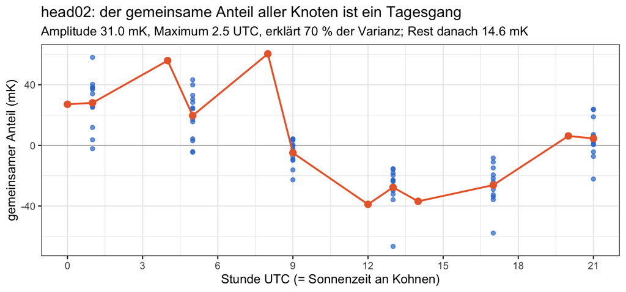

```r
if (!is.null(h02)) {
  cm_df <- data.frame(recv = bar02$recv, cm = cm, hr = as.integer(format(bar02$recv, "%H")))
  hfit  <- lm(cm ~ cos(2 * pi * hr / 24) + sin(2 * pi * hr / 24), data = cm_df)
  amp   <- sqrt(sum(coef(hfit)[2:3]^2))
  phase <- (atan2(coef(hfit)[3], coef(hfit)[2]) * 12 / pi) %% 24

  ggplot(cm_df, aes(hr, cm)) +
    geom_hline(yintercept = 0, colour = "grey70") +
    geom_point(size = 1.8, colour = "#2a78d6", alpha = 0.7) +
    stat_summary(fun = mean, geom = "line", colour = "#eb6834", linewidth = 0.9) +
    stat_summary(fun = mean, geom = "point", colour = "#eb6834", size = 3) +
    scale_x_continuous(breaks = seq(0, 21, 3), name = "Stunde UTC (= Sonnenzeit an Kohnen)") +
    labs(title = "head02: der gemeinsame Anteil aller Knoten ist ein Tagesgang",
         subtitle = sprintf("Amplitude %.1f mK, Maximum %.1f UTC, erklärt %.0f %% der Varianz; Rest danach %.1f mK",
                            amp, phase, 100 * summary(hfit)$r.squared, sd(resid(hfit))),
         y = "gemeinsamer Anteil (mK)") +
    theme_bw(base_size = 13)
}
```

**Die naheliegende Erklärung — Einstrahlung über die Elektronik — scheidet aus.** Der Kopf liegt 8–10 m tief im Firn, dort gibt es keinen Tagesgang, und genau das zeigen die Hauskanäle:

```r
if (!is.null(h02)) {
  head_ch <- h02 |> filter(grepl("231708", Device)) |>
    transmute(recv = lubridate::dmy_hms(`Date Time (UTC)`, tz = "UTC"),
              nb = `Length (Bytes)`, hex = tolower(Payload)) |>
    filter(nb == 209, !grepl("6f6f", hex),
           recv > as.POSIXct("2026-01-20", tz = "UTC"),
           recv < as.POSIXct("2026-02-02 17:13", tz = "UTC")) |>
    mutate(adc_C = 6.101e-5 * strtoi(substr(hex, 9, 14), 16L) - 256.6,
           batt  = strtoi(substr(hex, nchar(hex) - 3, nchar(hex)), 16L),
           hr    = as.integer(format(recv, "%H"))) |>
    filter(adc_C > -50, adc_C < -35) |> arrange(recv)

  cm_ok <- cm_df |> filter(recv %in% head_ch$recv)
  gnd_cm <- nodes02 |> filter(node %in% c(2:12, 19:25), recv %in% head_ch$recv) |>
    group_by(recv) |> summarise(g = mean(gnd_dummy <- 0), .groups = "drop")   # Platzhalter

  diu <- function(v, hr) { f <- lm(v ~ cos(2*pi*hr/24) + sin(2*pi*hr/24))
    c(amp = unname(sqrt(sum(coef(f)[2:3]^2))),
      max = unname((atan2(coef(f)[3], coef(f)[2]) * 12/pi) %% 24),
      r2  = summary(f)$r.squared) }
  td_h <- as.numeric(difftime(head_ch$recv, min(head_ch$recv), units = "days"))
  d_adc  <- diu(resid(loess(head_ch$adc_C ~ td_h, span = 0.4)) * 1000, head_ch$hr)
  d_batt <- diu(resid(loess(head_ch$batt  ~ td_h, span = 0.4)),        head_ch$hr)
  d_cm   <- diu(cm_ok$cm, cm_ok$hr)

  knitr::kable(data.frame(
    Kanal = c("NTC1, gemeinsamer Anteil", "Platinentemperatur", "Batteriespannung"),
    `Tagesgang-Amplitude` = c(sprintf("%.1f mK", d_cm["amp"]), sprintf("%.0f mK", d_adc["amp"]),
                              sprintf("%.1f mV", d_batt["amp"])),
    `Maximum (UTC)` = round(c(d_cm["max"], d_adc["max"], d_batt["max"]), 1),
    `R²` = round(c(d_cm["r2"], d_adc["r2"], d_batt["r2"]), 2),
    `r mit dem gemeinsamen Anteil` = c("1.00",
      sprintf("%+.2f", cor(cm_ok$cm, head_ch$adc_C)), sprintf("%+.2f", cor(cm_ok$cm, head_ch$batt))),
    check.names = FALSE), row.names = FALSE,
    caption = "Nur die Knotenkanäle zeigen den Tagesgang; Platine und Batterie nicht.")
}
```

Nur die Knotenkanäle zeigen den Tagesgang; Platine und Batterie nicht.

| Kanal | Tagesgang-Amplitude | Maximum (UTC) | R² | r mit dem gemeinsamen Anteil |
| --- | --- | --- | --- | --- |
| NTC1, gemeinsamer Anteil | 28.1 mK | 2.2 | 0.75 | 1.00 |
| Platinentemperatur | 40 mK | 0.6 | 0.03 | +0.07 |
| Batteriespannung | 6.8 mV | 12.3 | 0.06 | -0.04 |

**Was der gemeinsame Anteil stattdessen ist: eine Verstärkungsänderung.** Ein additiver Nullpunktfehler und eine relative Verstärkungsänderung sehen in der Temperatur gleich aus, in den **Rohcounts** aber nicht: additiv verschiebt alle Knoten um denselben Betrag, multiplikativ proportional zum Messwert.

```r
if (!is.null(h02)) {
  deep_n <- c(2:12, 19:25)
  rC <- sapply(deep_n, function(nd) {
    z <- nodes02 |> filter(node == nd, recv %in% head_ch$recv) |> arrange(recv)
    td <- as.numeric(difftime(z$recv, min(z$recv), units = "days"))
    resid(loess(z$ntc ~ td, span = 0.4)) })
  lvl <- vapply(deep_n, function(nd) median(nodes02$ntc[nodes02$node == nd]), 0)
  slope_counts <- vapply(seq_along(deep_n), function(i) coef(lm(rC[, i] ~ cm_ok$cm))[2], 0)

  knitr::kable(data.frame(Knoten = deep_n, `Counts (Mio)` = round(lvl / 1e6, 2),
    `Counts je mK` = round(slope_counts, 1),
    `bei reiner Verstärkung erwartet` = round(lvl / mean(lvl) * mean(slope_counts), 1),
    check.names = FALSE) |> head(6), row.names = FALSE,
    caption = sprintf("Antwort der Rohcounts, erste sechs Knoten. Relative Verstärkungsänderung: %.1e je mK, bei 28 mK Amplitude %.1e — also rund 0,1 %%.",
                      abs(mean(slope_counts) / mean(lvl)), abs(28 * mean(slope_counts) / mean(lvl))))
}
```

Antwort der Rohcounts, erste sechs Knoten. Relative Verstärkungsänderung: 3.4e-05 je mK, bei 28 mK Amplitude 9.4e-04 — also rund 0,1 %.

| Knoten | Counts (Mio) | Counts je mK | bei reiner Verstärkung erwartet |
| --- | --- | --- | --- |
| 2 | 4.34 | -153.2 | -146.5 |
| 3 | 4.18 | -139.3 | -140.8 |
| 4 | 4.16 | -138.5 | -140.1 |
| 5 | 4.15 | -138.4 | -140.0 |
| 6 | 4.17 | -139.0 | -140.6 |
| 7 | 4.20 | -140.1 | -141.7 |

Die Antwort der Rohcounts folgt dem Pegel jedes Knotens und trifft die Erwartung für eine reine Verstärkungsänderung auf 1–5 %. Der gemeinsame Anteil ist damit eine **relative Änderung von rund 10⁻³** in der Messkette — Referenz, Teilerverhältnis oder ADC-Skala —, kein Nullpunktfehler. Das passt auch zum GND-Kanal: bei −780 Counts müsste eine 0,1-%-Verstärkungsänderung dort 0,8 Counts ausmachen, gemessen sind 0,77 Counts mit Maximum um 16 UTC (erwartet 14 UTC) — die richtige Größe, aber bei 4 Counts Streuung nicht signifikant.

Damit bleibt die **Ursache offen**. Gegen einen Temperatur- oder Versorgungseffekt sprechen die Hauskanäle. Und weil head02 zu sechs **festen** Uhrzeiten sendet, lassen sich ein echter 24-Stunden-Zyklus und ein von der Sendeslot-Nummer abhängiger Messzustand nicht trennen: eine Aufwärmzeit, eine Hauskeeping-Routine oder ein anderer Ablauf in bestimmten Slots sähe identisch aus.

**Ist das ein Defekt von head02?** Der Vergleich mit den anderen Kohnen-Köpfen führt nur mit der Bohrlochfüllung zum Ziel: **head03** (B50) hat eine luftgefüllte 60-m-Kette neben einer schneeverfüllten 10-m-Kette, **head04** (B40) eine 200-m-Kette im offenen Bohrloch neben einer flachen Kette in Schnee. In luftgefüllten Löchern korrelieren die Sensoren ohnehin — das ist die Advektion der Bohrlochluft aus dem vorigen Kapitel, nicht die Messkette.

Die Auswertung steht in `../KohnenRecords_Analyse/head02_profile.qmd`; das Ergebnis trennt beides sauber: bei **head03** korrelieren die Knoten innerhalb der Luft-Kette mit r = 0,99 (4,8 mK) und innerhalb der Schnee-Kette mit r = 0,87 (0,8 mK), **zwischen den Ketten aber nur mit r = 0,10**; bei **head04** innerhalb des Bohrlochs r = 0,94 (6,7 mK), zur Kette in Schnee r = 0,01. Ein Störer der Messkette müsste beide Ketten gleich treffen — er tut es nicht. head03 und head04 haben also **keinen** gemeinsamen Anteil der Elektronik.

Bei **head02** liegen dagegen beide Ketten in Schnee, in zwei getrennten Bohrlöchern, und die Korrelation von 1,00 läuft über 0,2 bis 62 m hinweg. Bohrlochluft scheidet damit aus; zusammen mit dem Verstärkungscharakter und dem Tagesgang bleibt die Messkette.

### Mit der Tiefentabelle: die Tiefenabhängigkeit bei Kohnen

Der gemeinsame Anteil ist die Hürde — 26 mK gegen ein erwartetes Drucksignal von 0,5 mK, und bei einer Knoten-Korrelation von 1,00 mittelt er sich nicht weg. **Herausrechnen lässt er sich aber**, und dann trägt head02 mehr bei als die Grönland-Kette, weil die Tiefen von 0,2 bis 62 m reichen. Abfragereihenfolge und Tiefen stehen in `KohnenRecords_Analyse/data/head02_depths.csv`: Position 1 ist der Lufttemperatursensor in 2 m Höhe, Positionen 2–12 die **60-m-Kette** (5, 8, 10, 13, 16, 21, 26, 32, 40, 50, 62 m), Positionen 13–25 die **10-m-Kette** (0,2 bis 10 m). Beide sind in Schnee verfüllt.

```r
if (!is.null(h02)) {
  dmap <- readr::read_csv("../KohnenRecords_Analyse/data/head02_depths.csv", show_col_types = FALSE)
  n02  <- nodes02 |> filter(recv %in% head_ch$recv) |>
    left_join(dmap, by = c("node" = "position")) |> arrange(node, recv)

  td02b <- as.numeric(difftime(sort(unique(n02$recv)), min(n02$recv), units = "days"))
  rP02  <- resid(loess(as.numeric(tapply(n02$p, n02$recv, mean)) ~ td02b, span = 0.4))
  Rn <- sapply(sort(unique(n02$node)), function(nd) {
    z <- n02 |> filter(node == nd) |> arrange(recv)
    resid(loess(z$T ~ td02b, span = 0.4)) * 1000 })
  info <- dmap[match(sort(unique(n02$node)), dmap$position), ]
  CMn  <- rowMeans(Rn[, info$depth_m >= 13 & info$chain == "60m-Kette"])

  # Dichteprofil Kohnen: Herron-Langway mit T = 228.6 K, A = 0.064 m w.e./a
  Tk <- 228.6; Ak <- 0.064; c_i2 <- 152.5 + 7.122 * Tk
  k0k <- 11 * exp(-10160/(8.314*Tk)); k1k <- 575 * exp(-21400/(8.314*Tk))
  z550k <- (log(.55/(.917-.55)) - log(.34/(.917-.34)))/(.917*k0k)
  densk <- function(z) vapply(z, function(q) {
    Z <- if (q <= z550k) exp(.917*k0k*q + log(.34/(.917-.34)))
         else exp(.917*k1k*(q - z550k)/sqrt(Ak) + log(.55/(.917-.55)))
    .917*Z/(1+Z) }, 0)
  bthk <- function(z) { r <- densk(z)*1000; (1 - r/917)/(r*c_i2)*1e5 }

  h02b <- bind_rows(lapply(which(info$depth_m >= 4), function(i) {
    f <- summary(lm(Rn[, i] ~ CMn + rP02))$coefficients
    data.frame(depth_m = info$depth_m[i], chain = info$chain[i],
               b = f[3,1], se = f[3,2], t = f[3,3],
               rest = sd(resid(lm(Rn[, i] ~ CMn))), theorie = bthk(info$depth_m[i])) }))

  tief <- h02b |> filter(chain == "60m-Kette", depth_m >= 13)
  ff   <- summary(lm(b ~ theorie, data = tief, weights = 1/se^2))

  knitr::kable(h02b |> arrange(chain, depth_m) |>
      transmute(`Tiefe (m)` = depth_m, Kette = chain,
      `b (mK/hPa)` = round(b, 4), `t` = round(t, 1),
      `Theorie φ/(ρc)` = round(theorie, 4), `Restrauschen (mK)` = round(rest, 2)),
    row.names = FALSE,
    caption = sprintf("head02 nach Abzug des gemeinsamen Anteils. Formtest über 13–62 m: gemessen = %.2f ± %.2f × Theorie (t = %.1f), Korrelation %.2f.",
                      ff$coefficients[2,1], ff$coefficients[2,2], ff$coefficients[2,3],
                      cor(tief$b, tief$theorie)))
}
```

head02 nach Abzug des gemeinsamen Anteils. Formtest über 13–62 m: gemessen = 0.67 ± 0.17 × Theorie (t = 3.9), Korrelation 0.93.

| Tiefe (m) | Kette | b (mK/hPa) | t | Theorie φ/(ρc) | Restrauschen (mK) |
| --- | --- | --- | --- | --- | --- |
| 4 | 10m-Kette | 0.1953 | 9.7 | 0.0857 | 0.41 |
| 5 | 10m-Kette | 0.1560 | 7.5 | 0.0817 | 0.37 |
| 6 | 10m-Kette | 0.1288 | 6.2 | 0.0779 | 0.34 |
| 7 | 10m-Kette | 0.1165 | 5.3 | 0.0742 | 0.35 |
| 8 | 10m-Kette | 0.1113 | 5.0 | 0.0707 | 0.34 |
| 9 | 10m-Kette | 0.0995 | 4.5 | 0.0674 | 0.33 |
| 10 | 10m-Kette | 0.1008 | 4.5 | 0.0642 | 0.33 |
| 5 | 60m-Kette | 0.1308 | 6.6 | 0.0817 | 0.33 |
| 8 | 60m-Kette | 0.0336 | 3.2 | 0.0707 | 0.15 |
| 10 | 60m-Kette | 0.0327 | 3.6 | 0.0642 | 0.13 |
| 13 | 60m-Kette | 0.0180 | 3.0 | 0.0556 | 0.08 |
| 16 | 60m-Kette | 0.0094 | 1.7 | 0.0481 | 0.07 |
| 21 | 60m-Kette | 0.0080 | 1.8 | 0.0392 | 0.06 |
| 26 | 60m-Kette | -0.0070 | -2.1 | 0.0342 | 0.05 |
| 32 | 60m-Kette | -0.0016 | -0.4 | 0.0291 | 0.06 |
| 40 | 60m-Kette | -0.0010 | -0.2 | 0.0235 | 0.06 |
| 50 | 60m-Kette | -0.0112 | -2.1 | 0.0180 | 0.07 |
| 62 | 60m-Kette | -0.0145 | -2.1 | 0.0130 | 0.09 |

Zur Kalibrierung: die Umrechnung läuft über die universelle Mean-S4-Kurve, der gedämpfte Bereich kommt damit auf −40,5 °C statt der für Kohnen bekannten −44,5 °C. Für die hier ausgewerteten Steigungen ist nur die lokale Empfindlichkeit maßgeblich, der Versatz selbst spielt keine Rolle.

**Was daraus für künftige Auslegungen folgt:** Die 4-stündliche Abtastung wäre der richtige Weg, und 60 m Verfüllung gäben den Hebel für die Tiefenabhängigkeit. Der begrenzende Faktor ist der Common Mode. Ein mitgemessener Referenzwiderstand oder ein Knoten in konstanter Umgebung würde ihn abziehbar machen; dann läge das Restrauschen bei 0,9 mK je Knoten und der Effekt wäre über die Tiefenstaffelung auflösbar.

## head03 (B50): sechs Monate, 38 hPa Druckhub

head03 misst an B50 mit drei Ketten — einer **luftgefüllten 60-m-Kette** (11 Knoten), einer **schneeverfüllten 10-m-Kette** (13 Knoten) und einem **2-m-Schacht in Schnee** (10 Knoten), dazu ein Wetterstationsknoten. Alle 35 Knoten messen Druck, zweimal täglich (09 und 21 UTC) von Januar bis Juli 2026. Das ist der längste Datensatz und der größte Druckhub.

```r
h03 <- tryCatch(readr::read_csv("../KohnenRecords_Analyse/data/decoded_head03_231709_combined.csv",
                                show_col_types = FALSE), error = function(e) NULL)
d03 <- tryCatch(readr::read_csv("../KohnenRecords_Analyse/data/head03_depths.csv",
                                show_col_types = FALSE), error = function(e) NULL)
ok03 <- !is.null(h03) && !is.null(d03)

if (ok03) {
  h03 <- h03[order(h03$time_utc), ]
  td3 <- as.numeric(difftime(h03$time_utc, min(h03$time_utc), units = "days"))
  P3  <- sapply(d03$node, function(n) h03[[sprintf("n%d.pressure_hPa", n)]])
  bar3 <- rowMeans(P3, na.rm = TRUE)
  A3   <- P3 - bar3
}
```

### Taugen die Drucksensoren?

```r
if (ok03) {
  mon <- format(h03$time_utc, "%Y-%m")
  sais <- aggregate(bar3, list(Monat = mon), function(v) c(sd = sd(v), sp = diff(range(v))))
  knitr::kable(data.frame(Monat = sais$Monat, `sd (hPa)` = round(sais$x[, "sd"], 2),
                          `Spannweite (hPa)` = round(sais$x[, "sp"], 1), check.names = FALSE),
    row.names = FALSE, caption = "Variabilität des barometrischen Signals (Mittel aller 35 Sensoren) je Monat.")
}
```

Variabilität des barometrischen Signals (Mittel aller 35 Sensoren) je Monat.

| Monat | sd (hPa) | Spannweite (hPa) |
| --- | --- | --- |
| 2026-01 | 3.80 | 15.5 |
| 2026-02 | 3.57 | 16.0 |
| 2026-03 | 7.36 | 32.1 |
| 2026-04 | 4.98 | 20.1 |
| 2026-05 | 7.69 | 31.5 |
| 2026-06 | 7.59 | 38.3 |
| 2026-07 | 6.15 | 22.0 |

Der andere Teil ist der Sensor:

```r
if (ok03) {
  sens <- bind_rows(lapply(seq_len(nrow(d03)), function(i) {
    a <- A3[, i]; tt <- h03[[sprintf("n%d.ntc1_temp_C", d03$node[i])]]
    if (sum(is.finite(a)) < 100) return(NULL)
    okk <- is.finite(a)
    r <- resid(loess(a[okk] ~ td3[okk], span = 0.3))
    da <- diff(a) * 100; dt <- diff(tt); o2 <- is.finite(da) & is.finite(dt)
    tc <- if (sum(o2) > 50 && diff(range(tt, na.rm = TRUE)) > 10)
            summary(lm(da[o2] ~ dt[o2]))$coefficients[2, ] else c(NA, NA, NA, NA)
    data.frame(chain = d03$chain[i], depth_m = d03$depth_m[i],
               offset = mean(a, na.rm = TRUE), roh = sd(a, na.rm = TRUE) * 100,
               detr = sd(r) * 100, drift = coef(lm(a[okk] ~ td3[okk]))[2] * 30 * 100,
               Thub = diff(range(tt, na.rm = TRUE)), tc = tc[1], tc_t = tc[3]) }))

  knitr::kable(sens |> filter(!is.na(depth_m)) |>
      mutate(grp = ifelse(grepl("Luft", chain), "60 m, Luft",
                   ifelse(grepl("10 m", chain), "10 m, Schnee", "2 m Schacht"))) |>
      group_by(Kette = grp) |>
      summarise(`Offset (hPa)` = sprintf("%.1f … %+.1f", min(offset), max(offset)),
                `Streuung roh (Pa)` = sprintf("%.0f–%.0f", min(roh), max(roh)),
                `nach Trendabzug (Pa)` = sprintf("%.0f–%.0f", min(detr), max(detr)),
                `Drift (Pa/Monat)` = sprintf("%+.0f … %+.0f", min(drift), max(drift)),
                `T-Koeffizient (Pa/K)` = ifelse(all(is.na(tc)), "—",
                   sprintf("%+.0f … %+.0f", min(tc, na.rm = TRUE), max(tc, na.rm = TRUE))),
                .groups = "drop"),
    caption = "Drucksensoren head03: Offsets, Streuung, Drift und Temperaturkoeffizient (aus Tagesdifferenzen, nur Knoten mit über 10 K Temperaturhub).")
}
```

Drucksensoren head03: Offsets, Streuung, Drift und Temperaturkoeffizient (aus Tagesdifferenzen, nur Knoten mit über 10 K Temperaturhub).

| Kette | Offset (hPa) | Streuung roh (Pa) | nach Trendabzug (Pa) | Drift (Pa/Monat) | T-Koeffizient (Pa/K) |
| --- | --- | --- | --- | --- | --- |
| 10 m, Schnee | -5.4 … +5.3 | 263–898 | 61–511 | -212 … +376 | -1 … +254 |
| 2 m Schacht | -6.9 … +9.1 | 163–1345 | 71–337 | -239 … +636 | +24 … +278 |
| 60 m, Luft | -0.8 … +10.1 | 174–284 | 59–147 | -103 … +83 | — |

Ein Teil dieser Streuung ist **nicht** Temperaturkoeffizient, sondern ein **Skalenfehler** (die geschädigten Sensoren bleiben in der Referenz von hier an außen vor): misst ein Sensor den barometrischen Hub um einige Prozent anders als die anderen, erscheint das in seiner Anomalie als Rauschen. Beides lässt sich trennen — der Skalenfehler aus der Regression der Tagesdifferenzen auf das Netzmittel, der Temperaturkoeffizient daneben:

```r
if (ok03) {
  dbar <- diff(bar3)
  sc <- bind_rows(lapply(seq_len(nrow(d03)), function(i) {
    a <- P3[, i]; tt <- h03[[sprintf("n%d.ntc1_temp_C", d03$node[i])]]
    if (sum(is.finite(a)) < 100) return(NULL)
    da <- diff(a); okk <- is.finite(da) & is.finite(dbar)
    f <- summary(lm(da[okk] ~ dbar[okk]))
    dt <- diff(tt); o2 <- okk & is.finite(dt)
    tc <- if (diff(range(tt, na.rm = TRUE)) > 10)
            summary(lm(I(da[o2]*100) ~ dt[o2] + I(dbar[o2]*100)))$coefficients[2, 1] else NA
    data.frame(depth_m = d03$depth_m[i], tmin = min(tt, na.rm = TRUE),
               scale = f$coefficients[2, 1], resid_Pa = sd(resid(f)) * 100, tc = tc) }))

  sc <- sc |> mutate(grp = cut(tmin, c(-70, -50, -45, 0),
                               labels = c("kälter als −50 °C", "−50 bis −45 °C", "wärmer als −45 °C")))
  knitr::kable(sc |> group_by(`kälteste erreichte Temperatur` = grp) |>
      summarise(`Sensoren` = n(),
                `Skalenfaktor (Median)` = round(median(scale), 3),
                `Skalenfaktor (Spanne)` = sprintf("%.2f–%.2f", min(scale), max(scale)),
                `Reststreuung (Pa)` = sprintf("%.0f (%.0f–%.0f)", median(resid_Pa), min(resid_Pa), max(resid_Pa)),
                `T-Koeffizient (Pa/K)` = ifelse(all(is.na(tc)), "—",
                    sprintf("%.0f", median(tc, na.rm = TRUE))), .groups = "drop"),
    caption = "Die Sensoren verlieren unterhalb von etwa −50 °C an Verstärkung und werden unruhig.")
}
```

Die Sensoren verlieren unterhalb von etwa −50 °C an Verstärkung und werden unruhig.

| kälteste erreichte Temperatur | Sensoren | Skalenfaktor (Median) | Skalenfaktor (Spanne) | Reststreuung (Pa) | T-Koeffizient (Pa/K) |
| --- | --- | --- | --- | --- | --- |
| kälter als −50 °C | 11 | 0.884 | 0.82–1.08 | 95 (42–508) | 89 |
| −50 bis −45 °C | 6 | 1.052 | 0.86–1.08 | 37 (30–64) | 88 |
| wärmer als −45 °C | 18 | 1.077 | 0.81–1.10 | 34 (26–36) | — |

### Wie sich der Fehler mit dem Druck ändert

Referenz ist im Folgenden **nicht mehr das Mittel aller 35 Sensoren**, sondern nur das der 18, die nie unter −45 °C waren — die geschädigten bleiben außen vor.

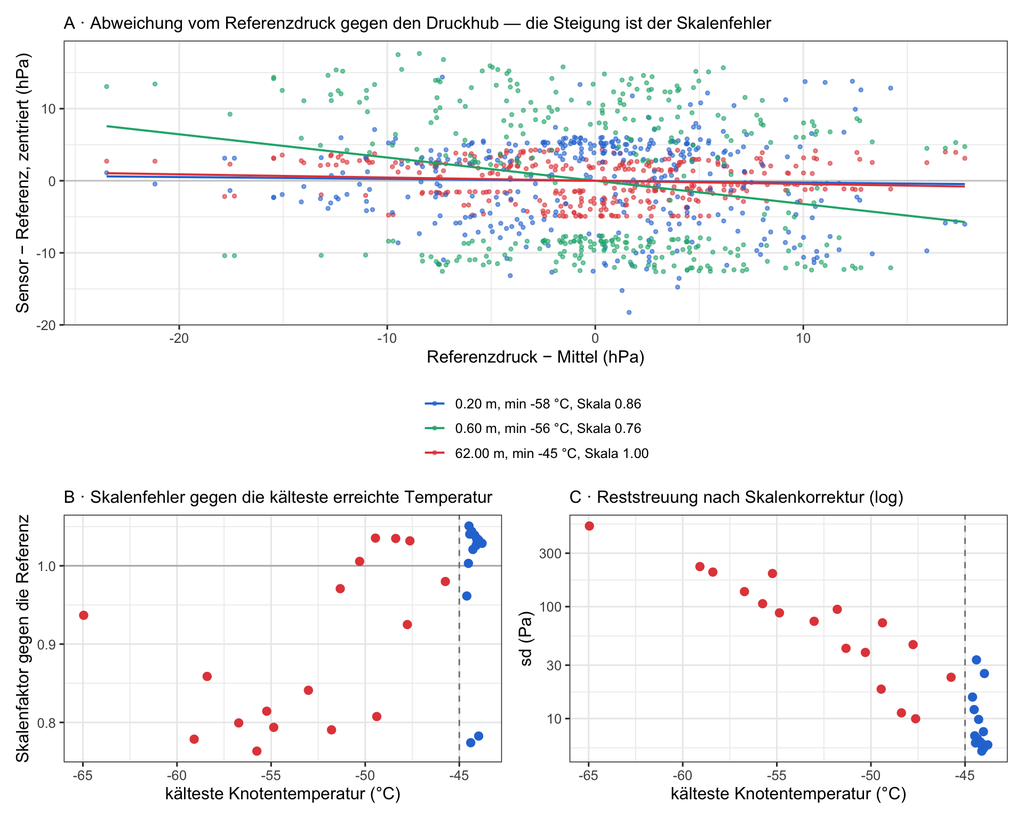

```r
if (ok03) {
  Tmin3 <- vapply(d03$node, function(n) min(h03[[sprintf("n%d.ntc1_temp_C", n)]], na.rm = TRUE), 0)
  ref3  <- rowMeans(P3[, Tmin3 > -45], na.rm = TRUE)

  # Skala und Kurzzeit-Treue aus Tagesdifferenzen (ohne die langsame Drift),
  # Drift getrennt aus den Niveaus.
  dref <- diff(ref3)
  sc2 <- bind_rows(lapply(seq_len(nrow(d03)), function(i) {
    da <- diff(P3[, i]); okk <- is.finite(da) & is.finite(dref)
    f  <- summary(lm(da[okk] ~ dref[okk]))
    lv <- summary(lm(P3[, i] ~ ref3))
    data.frame(i = i, chain = d03$chain[i], depth_m = d03$depth_m[i], tmin = Tmin3[i],
               scale = f$coefficients[2, 1], resid_Pa = sd(resid(f)) * 100,
               resid_lv = sd(resid(lv)) * 100) }))

  # drei Beispielsensoren: intakt, mittel, stark geschädigt
  bsp <- c(sc2$i[which.min(abs(sc2$scale - 1) + (sc2$tmin < -45) * 9)],
           sc2$i[which.min(abs(sc2$scale - 0.85))],
           sc2$i[which.min(sc2$scale)])
  lbl <- sprintf("%.2f m, min %.0f °C, Skala %.2f", d03$depth_m[bsp], Tmin3[bsp], sc2$scale[bsp])

  pA <- bind_rows(lapply(seq_along(bsp), function(k)
      data.frame(ref = ref3 - mean(ref3), dev = P3[, bsp[k]] - ref3, s = lbl[k]))) |>
    ggplot(aes(ref, dev - ave(dev, s, FUN = function(v) mean(v, na.rm = TRUE)), colour = s)) +
    geom_hline(yintercept = 0, colour = "grey80") +
    geom_point(size = 1, alpha = 0.6) +
    geom_smooth(method = "lm", se = FALSE, linewidth = 0.7) +
    scale_colour_manual(values = c("#2a78d6", "#1baf7a", "#e34948"), name = NULL) +
    labs(subtitle = "A · Abweichung vom Referenzdruck gegen den Druckhub — die Steigung ist der Skalenfehler",
         x = "Referenzdruck − Mittel (hPa)", y = "Sensor − Referenz, zentriert (hPa)") +
    theme_bw(base_size = 12) + theme(legend.position = "bottom", legend.direction = "vertical")

  pB <- ggplot(sc2, aes(tmin, scale, colour = ifelse(tmin > -45, "über −45 °C", "kälter"))) +
    geom_hline(yintercept = 1, colour = "grey70") +
    geom_vline(xintercept = -45, linetype = "dashed", colour = "grey50") +
    geom_point(size = 2.4) +
    scale_colour_manual(values = c("über −45 °C" = "#2a78d6", "kälter" = "#e34948"), name = NULL) +
    labs(subtitle = "B · Skalenfehler gegen die kälteste erreichte Temperatur",
         x = "kälteste Knotentemperatur (°C)", y = "Skalenfaktor gegen die Referenz") +
    theme_bw(base_size = 12) + theme(legend.position = "none")

  pC <- ggplot(sc2, aes(tmin, resid_Pa, colour = ifelse(tmin > -45, "über −45 °C", "kälter"))) +
    geom_vline(xintercept = -45, linetype = "dashed", colour = "grey50") +
    geom_point(size = 2.4) +
    scale_y_log10() +
    scale_colour_manual(values = c("über −45 °C" = "#2a78d6", "kälter" = "#e34948"), name = NULL) +
    labs(subtitle = "C · Reststreuung nach Skalenkorrektur (log)",
         x = "kälteste Knotentemperatur (°C)", y = "sd (Pa)") +
    theme_bw(base_size = 12) + theme(legend.position = "none")

  patchwork::wrap_plots(pA, patchwork::wrap_plots(pB, pC, ncol = 2), ncol = 1, heights = c(1.15, 1))
}
```

Panel A zeigt, worin der Fehler besteht: die Abweichung vom Referenzdruck ist **keine Konstante, sondern wächst mit dem Druckhub**. Ein intakter Sensor liegt waagerecht, der geschädigte folgt dem Barometer nur zu einem Bruchteil — bei 41 hPa Hub summiert sich das auf mehrere hPa.

Panel B und C ordnen das der Temperatur zu. Der Schaden ist dabei **nicht** allein ein Skalenfaktor, den man wegrechnen könnte: auch nach der Skalenkorrektur bleibt die Streuung der kalten Sensoren zehn- bis hundertfach über der der intakten. Dazu kommt die langsame Drift, die in den Niveaus steckt und in dieser Rechnung gar nicht auftaucht.

### Wie kalt darf es werden? Der Knick liegt bei −45 °C

Die oberflächennahen Sensoren durchlaufen im Jahresgang −25 bis −58 °C. Damit lässt sich die Kennlinie **innerhalb desselben Sensors** aufnehmen — Bauteilstreuung fällt heraus.

[figure not shown]

```r
if (ok03) {
  Tn3 <- sapply(d03$node, function(n) h03[[sprintf("n%d.ntc1_temp_C", n)]])
  Tmin3b <- apply(Tn3, 2, min, na.rm = TRUE); Tmax3 <- apply(Tn3, 2, max, na.rm = TRUE)
  ref3b <- rowMeans(P3[, Tmin3b > -45], na.rm = TRUE); dref3 <- diff(ref3b)
  wide <- which(Tmax3 - Tmin3b > 15)                    # Sensoren mit großem eigenem Hub

  lg <- bind_rows(lapply(wide, function(i) {
    da <- diff(P3[, i]); tt <- Tn3[-1, i]; okk <- is.finite(da) & is.finite(tt)
    data.frame(da = da[okk], dref = dref3[okk], temp = tt[okk], node = i) })) |>
    mutate(bin = cut(temp, seq(-60, -20, 5)))

  knick <- bind_rows(lapply(levels(lg$bin), function(b) {
    sub <- lg |> filter(bin == b); if (nrow(sub) < 100) return(NULL)
    per <- bind_rows(lapply(unique(sub$node), function(nd) {
      z <- sub |> filter(node == nd); if (nrow(z) < 20) return(NULL)
      data.frame(scale = unname(coef(lm(da ~ dref, z))[2]),
                 sd_Pa = sd(resid(lm(da ~ dref, z))) * 100) }))
    data.frame(bin = b, mid = mean(as.numeric(strsplit(gsub("[(\\]]", "", b), ",")[[1]])),
               scale = median(per$scale), sd_Pa = median(per$sd_Pa), n = nrow(per)) }))

  p1 <- ggplot(knick, aes(mid, scale)) +
    geom_hline(yintercept = 1, colour = "grey70") +
    geom_vline(xintercept = -45, linetype = "dashed", colour = "#eb6834") +
    geom_line(colour = "#2a78d6", linewidth = 0.7) + geom_point(colour = "#2a78d6", size = 2.6) +
    labs(subtitle = "Skalenfaktor", x = "Sensortemperatur (°C)", y = "Skala gegen die Referenz") +
    theme_bw(base_size = 12)
  p2 <- ggplot(knick, aes(mid, sd_Pa)) +
    geom_vline(xintercept = -45, linetype = "dashed", colour = "#eb6834") +
    geom_line(colour = "#2a78d6", linewidth = 0.7) + geom_point(colour = "#2a78d6", size = 2.6) +
    scale_y_log10() +
    labs(subtitle = "Reststreuung (log)", x = "Sensortemperatur (°C)", y = "sd (Pa)") +
    theme_bw(base_size = 12)
  patchwork::wrap_plots(p1, p2, ncol = 2)

}
```

```r
if (ok03) knitr::kable(knick |> arrange(mid) |>
  transmute(`Sensortemperatur` = bin, `Skala (Median)` = round(scale, 3),
            `Reststreuung (Pa)` = round(sd_Pa, 0), `Sensoren` = n), row.names = FALSE,
  caption = "Innerhalb derselben Sensoren, aufgenommen über den Jahresgang.")
```

Innerhalb derselben Sensoren, aufgenommen über den Jahresgang.

| Sensortemperatur | Skala (Median) | Reststreuung (Pa) | Sensoren |
| --- | --- | --- | --- |
| (-60,-55] | 0.699 | 288 | 3 |
| (-55,-50] | 0.667 | 128 | 9 |
| (-50,-45] | 0.824 | 98 | 13 |
| (-45,-40] | 1.017 | 10 | 13 |
| (-40,-35] | 1.009 | 4 | 8 |
| (-35,-30] | 1.006 | 2 | 13 |
| (-30,-25] | 1.002 | 2 | 8 |

Oberhalb von −40 °C arbeitet der DPS368 exakt nach Datenblatt: Skala 1,00 ± 0,01, Reststreuung 2–5 Pa. Zwischen −40 und −45 °C bleibt die Skala im Median bei 1,02, die Streuung **zwischen** den Exemplaren springt aber auf ±0,19. Unter −45 °C bricht es weg: bei −45 bis −50 °C Skala 0,82 und rund 100 Pa, bei −50 bis −55 °C Skala 0,67 und rund 130 Pa, darunter 0,70 und rund 290 Pa. Der Sensor gibt dann nur noch zwei Drittel der Druckänderung wieder.

Wichtig für die Kalibrierfrage: der Effekt ist **reversibel** — dieselben Sensoren liefern im Sommer wieder 2–5 Pa. Es ist kein bleibender Schaden, sondern der Arbeitspunkt.

### Was das für die kälteren Plateau-Standorte bedeutet

Kohnen ist mit −44,5 °C Jahresmittel einer der **wärmsten** Standorte des Plateaus. Die Jahresmitteltemperatur entspricht der Firntemperatur ab etwa 10 m Tiefe — also genau dem, was ein dort eingebauter Sensor dauerhaft sieht:

| Standort | Jahresmittel ≈ Firntemperatur | DPS368-Regime |
| --- | --- | --- |
| Kohnen | −44,5 °C | knapp oberhalb des Knicks; ab 4 m brauchbar |
| South Pole | −49,5 °C | Skala ≈ 0,82, rund 100 Pa |
| Dome F | −54,4 °C | Skala ≈ 0,67, rund 130 Pa |
| Dome C | −54,5 °C | Skala ≈ 0,67, rund 130 Pa |
| Vostok | −55,3 °C | Skala ≈ 0,70, rund 290 Pa |
| Dome A | −58,3 °C | jenseits des Gemessenen, ≥ 300 Pa |

Damit fällt die Kohnen-Lösung weg: dort half „erst ab 4 m bestücken”, weil es in der Tiefe mit −44 °C gerade noch über dem Knick bleibt. An Dome C, Vostok oder Dome A gibt es **keine Tiefe**, in der der DPS368 in seinem brauchbaren Bereich liefe — die Firntemperatur selbst liegt 5 bis 13 K unter dem Knick, und die oberste Schicht geht im Winter auf −70 bis −80 °C.

Für PlateauInSync folgt daraus:

- Ein Sensor **desselben Typs** liefert an den kalten Standorten dauerhaft 20–35 % Empfindlichkeitsverlust und 100–300 Pa Rauschen. Der Verlust ist systematisch und mittelt sich nicht weg; er verzerrt jede Auswertung, die den Druck als Referenz benutzt.
- Ein **Typwechsel**: ein Barometer, das bis −60 °C spezifiziert ist. Wenige gute Sensoren schlagen viele schlechte, weil der Skalenfehler nicht durch Mittelung verschwindet.
- Bleibt es beim DPS368, ist eine **Kammerkalibrierung bis −60 °C** möglich und sinnvoll — der Effekt ist reversibel und damit korrigierbar. Sie behebt aber nur die Skala, nicht das Rauschen: 100–300 Pa bleiben, gegenüber 2–5 Pa im spezifizierten Bereich.
- Und sie setzt voraus, dass **Rohdruck und Rohtemperatur** mitgeloggt werden; sonst lässt sich die werkseitige Kompensation nicht ersetzen.

### Der Sensor: DPS368, und was das Datenblatt dazu sagt

Verbaut ist der **Infineon DPS368**. Sein Datenblatt erklärt die Befunde:

| Größe | Datenblatt | gemessen Grönland (bis −31 °C) | Kohnen > −45 °C | Kohnen < −50 °C |
| --- | --- | --- | --- | --- |
| Betriebsbereich | −40 … +85 °C | eingehalten | 4 K darunter | 8–18 K darunter |
| Lagertemperatur (min) | −40 °C | eingehalten | unterschritten | unterschritten |
| Temperaturkoeffizient | 0,5 Pa/K (bei 25…65 °C) | 1–10 Pa/K | — | 25–280 Pa/K |
| Präzision | 0,2–1,0 Pa rms | 1–3 Pa | 34 Pa | 95 Pa |
| relative Genauigkeit | ±6 Pa (bei +20…+60 °C) | — | — | Skalenfehler 19 % |

Zwei Punkte dazu. **Erstens** gelten die Genauigkeitsangaben nur für den warmen Teil des Betriebsbereichs — die relative Genauigkeit für +20…+60 °C, der Temperaturkoeffizient für 25…+65 °C. Bereits bei −40 °C bewegt man sich in Extrapolation, und der Firn an B50 liegt mit −44,5 °C schon darunter. **Zweitens** rechnet der Chip den kompensierten Druck aus Rohdruck **und Rohtemperatur** mit werkseitigen Koeffizienten (c00, c10, c20, c30, c01, c11, c21). Die Temperatur-Kreuzterme c11 und c21 bestimmen dabei genau die **Empfindlichkeit** — werden sie weit außerhalb ihres Fitbereichs ausgewertet, entsteht ein Skalenfehler. Das beobachtete Bild (19 % Verstärkungsverlust, stark erhöhter Temperaturkoeffizient, dreifaches Rauschen) ist die Signatur dieser Extrapolation, nicht die eines defekten Sensors.

**Kalibrieren lässt sich das, mit drei Bedingungen:**

- **Rohwerte mitloggen.** Nur wenn Rohdruck und Rohtemperatur des DPS368 übertragen werden, lässt sich die Kompensation mit eigenen Koeffizienten nachrechnen — auch rückwirkend. Wird nur der bereits kompensierte Wert übertragen, bleibt lediglich eine additive Korrektur über die Knotentemperatur. Was die Firmware heute sendet, ist zu prüfen.
- **Kammerkalibrierung bis −60 °C** bei rund 650 hPa, je Sensor Offset, Skala und Temperaturgang. Erreichbar ist damit im besten Fall das Niveau der nicht geschädigten Sensoren, also rund 30 Pa — nicht die 1–3 Pa aus Grönland, denn dort waren die Sensoren im spezifizierten Bereich.
- **Reversibilität prüfen.** Unterhalb der Lagertemperatur von −40 °C garantiert das Datenblatt nichts mehr. Eine Kalibrierung ist nur brauchbar, wenn der Sensor nach dem Temperaturzyklus wieder denselben Wert liefert; das muss durch Auf- und Abkühlen verifiziert und nach jeder Saison kontrolliert werden.

Für den laufenden Datensatz geht es auch ohne Labor: die **relative** Kalibrierung gegen das Netz der intakten Sensoren — Skalenfaktor und Temperaturgang je Sensor — ist aus den Felddaten selbst bestimmbar und bringt die geschädigten Sensoren auf das Niveau der übrigen.

### Was head03 zur Druck-Temperatur-Kopplung beiträgt

head03 hat keinen gemeinsamen Anteil der Elektronik (siehe `head02_profile.qmd`), die Temperaturresiduen der verfüllten Kette lassen sich also **direkt** gegen den Luftdruck regressieren — ohne den Zwischenschritt, der bei head02 den Absolutwert kostet.

```r
if (ok03) {
  rP3 <- resid(loess(bar3 ~ td3, span = 0.15))
  Tk <- 228.6; Ak <- 0.064; c_i3 <- 152.5 + 7.122 * Tk
  k0k <- 11*exp(-10160/(8.314*Tk)); k1k <- 575*exp(-21400/(8.314*Tk))
  z55 <- (log(.55/(.917-.55)) - log(.34/(.917-.34)))/(.917*k0k)
  dn3 <- function(z) vapply(z, function(q) { Z <- if (q <= z55) exp(.917*k0k*q + log(.34/(.917-.34)))
    else exp(.917*k1k*(q - z55)/sqrt(Ak) + log(.55/(.917-.55))); .917*Z/(1+Z) }, 0)
  bt3 <- function(z) { r <- dn3(z)*1000; (1 - r/917)/(r*c_i3)*1e5 }

  cp3 <- bind_rows(lapply(which(grepl("10 m", d03$chain) & !is.na(d03$depth_m) & d03$depth_m >= 4),
    function(i) {
      y <- h03[[sprintf("n%d.ntc1_temp_C", d03$node[i])]]; okk <- is.finite(y)
      r <- resid(loess(y[okk] ~ td3[okk], span = 0.15)) * 1000
      f <- summary(lm(r ~ rP3[okk]))
      data.frame(depth_m = d03$depth_m[i], b = f$coefficients[2,1], se = f$coefficients[2,2],
                 t = f$coefficients[2,3], r2 = f$r.squared, sdT = sd(r),
                 theorie = bt3(d03$depth_m[i])) }))

  ff3 <- summary(lm(b ~ 0 + theorie, data = cp3 |> filter(depth_m >= 5), weights = 1/se^2))
  knitr::kable(cp3 |> transmute(`Tiefe (m)` = depth_m, `b (mK/hPa)` = round(b, 4),
      `t` = round(t, 1), `R²` = round(r2, 2), `Theorie φ/(ρc)` = round(theorie, 4),
      `Verhältnis` = round(b/theorie, 2), `sd(T-Residuum) (mK)` = round(sdT, 2)),
    row.names = FALSE,
    caption = sprintf("Verfüllte 10-m-Kette, ohne jede Korrektur. Gewichteter Faktor über 5–10 m: %.3f ± %.3f.",
                      ff3$coefficients[1,1], ff3$coefficients[1,2]))
}
```

Verfüllte 10-m-Kette, ohne jede Korrektur. Gewichteter Faktor über 5–10 m: 0.993 ± 0.004.

| Tiefe (m) | b (mK/hPa) | t | R² | Theorie φ/(ρc) | Verhältnis | sd(T-Residuum) (mK) |
| --- | --- | --- | --- | --- | --- | --- |
| 4 | 0.1053 | 3.3 | 0.03 | 0.0857 | 1.23 | 2.67 |
| 5 | 0.0786 | 3.4 | 0.03 | 0.0817 | 0.96 | 1.94 |
| 6 | 0.0718 | 4.2 | 0.05 | 0.0779 | 0.92 | 1.45 |
| 7 | 0.0722 | 6.5 | 0.10 | 0.0742 | 0.97 | 0.98 |
| 8 | 0.0715 | 11.1 | 0.26 | 0.0707 | 1.01 | 0.62 |
| 9 | 0.0671 | 20.3 | 0.53 | 0.0674 | 1.00 | 0.40 |
| 10 | 0.0638 | 41.9 | 0.83 | 0.0642 | 0.99 | 0.31 |

```r
if (ok03) {
  Tmin3 <- vapply(d03$node, function(n) min(h03[[sprintf("n%d.ntc1_temp_C", n)]], na.rm = TRUE), 0)
  warm  <- which(Tmin3 > -45)
  fac <- function(idx) {
    rr <- resid(loess(rowMeans(P3[, idx, drop = FALSE], na.rm = TRUE) ~ td3, span = 0.15))
    g <- bind_rows(lapply(which(grepl("10 m", d03$chain) & !is.na(d03$depth_m) & d03$depth_m >= 5),
      function(i) { y <- h03[[sprintf("n%d.ntc1_temp_C", d03$node[i])]]; okk <- is.finite(y)
        r <- resid(loess(y[okk] ~ td3[okk], span = 0.15)) * 1000
        f <- summary(lm(r ~ rr[okk]))$coefficients
        data.frame(b = f[2,1], se = f[2,2], th = bt3(d03$depth_m[i])) }))
    summary(lm(b ~ 0 + th, data = g, weights = 1/g$se^2))$coefficients[1, 1:2] }
  a1 <- fac(seq_len(ncol(P3))); a2 <- fac(warm)
  knitr::kable(data.frame(
    Referenz = c(sprintf("alle %d Sensoren", ncol(P3)), sprintf("nur die %d über −45 °C", length(warm))),
    `Faktor gegen φ/(ρc)` = sprintf("%.3f ± %.3f", c(a1[1], a2[1]), c(a1[2], a2[2])),
    check.names = FALSE), row.names = FALSE,
    caption = "Der Absolutwert der Kopplung hängt an der Qualität des Referenzbarometers.")
}
```

Der Absolutwert der Kopplung hängt an der Qualität des Referenzbarometers.

| Referenz | Faktor gegen φ/(ρc) |
| --- | --- |
| alle 35 Sensoren | 0.993 ± 0.004 |
| nur die 18 über −45 °C | 0.956 ± 0.004 |

Nicht verwertbar sind die beiden anderen Ketten: die **luftgefüllte** 60-m-Kette, weil die Advektion der Bohrlochluft dort zwei Größenordnungen über dem Effekt liegt, und der **2-m-Schacht**, weil dort das echte Firnsignal mit 100–700 mK dominiert. Der nutzbare Bereich beginnt bei rund 4 m Tiefe und endet, wo die Kette endet.

### Gibt es Sensoren, die kälter können?

Recherchestand, geordnet nach Bauform:

- **Gleiche Klasse (digitale MEMS-Barometer)** — Bosch BMP390/BMP581, TE MS5611/MS5837, ST LPS22, ScioSense ENS220, Infineon DPS310/DPS368: alle enden bei **−40 °C**. Ein Wechsel innerhalb dieser Familie bringt nichts.
- **Instrumentenklasse** — Paroscientific Digiquartz MET4/MET4A (Schwingquarz): **−50 … +60 °C**, Genauigkeit 0,08 hPa, Auflösung im µbar-Bereich ([Handbuch](https://paroscientific.com/pdf/8008-001_Manual_for_MET4_and_MET4A_Meteorological_Measurement_Systems.pdf)). Das ist ein vollständiges Gerät, kein Bauteil für einen Knoten — Größe, Leistungsaufnahme und Preis passen nur an die Station, nicht in die Kette. Und −50 °C liegt an Dome C oder Vostok immer noch am Rand.
- **Militär-/Luftfahrtklasse** — piezoresistive Transducer sind üblich bis −55 °C spezifiziert, aber analog: eigene Speisung, eigener ADC, mehr Bauraum und Strom.
- **Der Beweis, dass das Prinzip nicht die Grenze ist:** Vaisalas **BAROCAP** ist derselbe Sensortyp wie im DPS368 — ein kapazitiver Einkristall-Silizium-Drucksensor — und fliegt in der Radiosonde RS41 durch das ganze Profil, deren Temperatursensor bis **−95 °C** reicht ([Vaisala](https://www.vaisala.com/en/vaisala-barocapr-technology)). Der Unterschied liegt nicht in der Physik, sondern darin, über welchen Bereich kalibriert wird.

Das deckt sich mit dem Befund oben: der DPS368 **misst** bei −58 °C weiter, nur eben mit 0,7 statt 1,0 Empfindlichkeit — und im Sommer wieder mit 1,0. Eine eigene Kalibrierung bis −60 °C ist deshalb der naheliegende Weg; sie holt die Skala zurück, das erhöhte Rauschen bleibt.

**Die billigste Lösung ist aber, den Druck gar nicht in der Kette zu messen.** Gebraucht wird für die Kopplungskorrektur das **synoptische** Signal, und das ist ein großräumiges Feld: ein Barometer an der Station oder der Bodendruck aus einer Reanalyse leistet dasselbe. An B50 folgt das Netzmittel dem Barometer über 41 hPa Hub; ob ERA5 dort ebenso gut passt, lässt sich mit den vorhandenen Daten prüfen, sobald der Bodendruck heruntergeladen ist (die lokale ERA5-Datei enthält nur t2m und Niederschlag).

**Empfehlung für PlateauInSync**, nach Aufwand geordnet:

1. **Referenzdruck von außen** — Stationsbarometer oder Reanalyse. Kostet nichts, ist bei −60 °C nicht betroffen, reicht für die Kopplungskorrektur.
2. **Wenige DPS368 in der Tiefe**, mit eigener Kalibrierung bis −60 °C und mitgeloggten Rohwerten. Gibt zusätzlich den hydrostatischen Gradienten und damit eine unabhängige Kontrolle der Einbautiefe.
3. **Ein Instrument der Paroscientific-Klasse an der Station**, falls ein hochwertiger In-situ-Referenzdruck gewünscht ist — nicht je Knoten.

## Windpumpen prüfen — womit das ginge

Windpumpen wird oft behauptet und selten gemessen. Zwei Wege stehen offen, und der naheliegende ist der schlechtere.

### Über den Druck: braucht andere Instrumente

Windpumpen entsteht aus dem quasi-statischen Druckfeld, das der Wind über Sastrugi und Dünen aufbaut, plus turbulenten Fluktuationen. Beides hat Amplituden von **wenigen Pa** an der Oberfläche, und die Eindringtiefe wird von der **horizontalen Wellenlänge** gesetzt: eine Störung der Wellenlänge λ klingt mit `exp(−2πz/λ)` ab. Sastrugi mit λ = 1 m wirken also nur bis rund 0,16 m, Dünen mit λ = 20 m bis rund 3 m. Zeitlich liegt das im Sekundenbereich.

Daraus folgt die Spezifikation: **0,1–1 Pa Auflösung, 1–10 Hz Abtastung, Sensoren bei 0,05 bis 1 m Tiefe, dazu eine Windmessung** — und sinnvollerweise **differenziell** gegen einen Referenzsensor, weil ein Absolutbarometer 1 Pa auf 650 hPa nur mit perfekt stabilem Offset auflöst. Unsere Ketten messen absolut, einmal am Tag, mit 6 Pa im besten und 100–300 Pa im kalten Fall. Damit ist Windpumpen weder zu zeigen noch zu widerlegen; das bisherige „kein Windbezug gefunden” ist kein Gegenbeweis, sondern eine Aussage über die Abtastung.

**Vaisalas BAROCAP hilft dabei nicht.** Als kaufbare Module — PTB210 und BARO-1 — ist es auf **−40 … +60 °C** spezifiziert ([PTB210](https://docs.vaisala.com/v/u/B210942EN-E/en-US), [BARO-1](https://docs.vaisala.com/v/u/B211084EN-D/en-US)), also dieselbe Grenze wie beim DPS368. Das bis −95 °C betriebene BAROCAP-Element steckt in der Radiosonde RS41 und wird nicht als Bauteil verkauft. Für eine Windpumpen-Messung wäre ohnehin ein **Differenzdrucksensor** die richtige Bauform, nicht ein Absolutbarometer.

### Über die Temperatur: dafür ist unsere Kette gebaut

Windpumpen transportiert Luft und damit Wärme. Sein Effekt auf die Temperatur ist eine **erhöhte effektive Temperaturleitfähigkeit** in den obersten Dezimetern — in der Literatur werden Faktoren 1,5 bis 3 unter starkem Wind genannt. Da die Dämpfungslänge mit `d = √(2κ/ω)` skaliert, entspricht das 20 bis 70 % Änderung von d. Bei 0,1 mK Messrauschen im verfüllten Loch ist das eine große Zahl.

Der Test hat zwei Teile. Erstens müssen **Amplituden- und Phasendämpfung übereinstimmen** — für reine Wärmeleitung sind beide dasselbe d; Advektion bricht die Gleichheit. Zweitens muss `κ_eff` **nicht** mit der Windgeschwindigkeit variieren, wenn es Windpumpen nicht gibt.

```r
if (ok03) {
  sel <- which(grepl("Schacht", d03$chain) |
               (grepl("10 m", d03$chain) & !is.na(d03$depth_m) & d03$depth_m <= 3))
  jw <- bind_rows(lapply(sel, function(i) {
    y <- h03[[sprintf("n%d.ntc1_temp_C", d03$node[i])]]; okk <- is.finite(y)
    if (sum(okk) < 200) return(NULL)
    f <- lm(y[okk] ~ cos(2*pi*td3[okk]/365.25) + sin(2*pi*td3[okk]/365.25))
    data.frame(depth_m = d03$depth_m[i], amp = sqrt(sum(coef(f)[2:3]^2)),
               phase = (atan2(coef(f)[3], coef(f)[2]) * 365.25/(2*pi)) %% 365.25,
               chain = d03$chain[i]) }))
  fa <- lm(log(amp) ~ depth_m, jw); fp <- lm(phase ~ depth_m, jw)
  d_amp <- -1/coef(fa)[2]; d_ph <- (365.25/(2*pi))/abs(coef(fp)[2])
  om <- 2*pi/(365.25*86400); kap_eff <- d_amp^2 * om / 2

  knitr::kable(data.frame(
    Größe = c("Dämpfungslänge aus der Amplitude", "Dämpfungslänge aus der Phase",
              "effektive Temperaturleitfähigkeit", "Wärmeleitfähigkeit dazu (ρ = 340 kg/m³)"),
    Wert = c(sprintf("%.2f m (R² = %.3f)", d_amp, summary(fa)$r.squared),
             sprintf("%.2f m (%.1f Tage Verzug je Meter)", d_ph, abs(coef(fp)[2])),
             sprintf("%.2e m²/s", kap_eff),
             sprintf("%.2f W/(m·K)", kap_eff * 340 * (152.5 + 7.122 * 228.6)))), row.names = FALSE,
    caption = "Jahreswelle in den obersten 2,25 m an B50 (Schacht und flache Kette).")
}
```

Jahreswelle in den obersten 2,25 m an B50 (Schacht und flache Kette).

| Größe | Wert |
| --- | --- |
| Dämpfungslänge aus der Amplitude | 1.74 m (R² = 0.978) |
| Dämpfungslänge aus der Phase | 1.58 m (36.7 Tage Verzug je Meter) |
| effektive Temperaturleitfähigkeit | 3.03e-07 m²/s |
| Wärmeleitfähigkeit dazu (ρ = 340 kg/m³) | 0.18 W/(m·K) |

Belastbar ist das noch nicht: der 2-m-Schacht ist **verfüllt**, seine Permeabilität muss nicht der des ungestörten Firns entsprechen, die Reihe deckt nur ein halbes Jahr ab, und zwei Messungen am Tag lösen die Tageswelle nicht auf.

### Würden wir Windpumpen oder Rektifikation in 2 m Tiefe überhaupt sehen?

Zwei Behauptungen stehen im Raum: Windpumpen bis in etwa 2 m Tiefe, und die **saisonale Rektifikation** von [Morgan et al. (2022)](https://tc.copernicus.org/articles/16/2947/2022/) — eine langsame Abwärtsbewegung der Firnluft, die im Winter stattfindet und im Sommer nicht, und die Gasrekorde um bis zu ±0,008 ‰ in δ¹⁵N_excess (rund ±3 °C im rekonstruierten Temperaturgradienten) verschiebt. Als Ursache diskutieren sie unter anderem winterliche Rayleigh-Bénard-Konvektion unter der Oberflächeninversion.

**Die Voraussetzungen sind an Kohnen erfüllt.** Der 2-m-Schacht von head03 ist von März bis Juli instabil geschichtet — oben 6,4 bis 8,6 K kälter als unten, die Porenluft oben also dichter. Die Rayleigh-Darcy-Zahl `Ra = gβkΔTH/(νκ)` liegt bei 90 bis 2750, weit über dem kritischen Wert von 4π² ≈ 39,5.

```r
if (ok03) {
  pit <- d03 |> filter(grepl("Schacht", chain)) |> arrange(depth_m)
  Rp <- sapply(pit$node, function(n) { y <- h03[[sprintf("n%d.ntc1_temp_C", n)]]; o <- is.finite(y)
    r <- rep(NA_real_, length(y)); r[o] <- resid(loess(y[o] ~ td3[o], span = 0.08)); r })
  strat_all <- h03[[sprintf("n%d.ntc1_temp_C", pit$node[1])]] -
               h03[[sprintf("n%d.ntc1_temp_C", pit$node[nrow(pit)])]]
  brk <- seq(min(td3), max(td3) - 30, by = 30)
  win <- bind_rows(lapply(brk, function(b) {
    i <- which(td3 >= b & td3 < b + 30); if (length(i) < 30) return(NULL)
    sdv <- apply(Rp[i, ], 2, sd, na.rm = TRUE); okk <- is.finite(sdv) & sdv > 0
    f <- lm(log(sdv[okk]) ~ pit$depth_m[okk])
    data.frame(ab = format(min(h03$time_utc[i]), "%d.%m."),
               strat = mean(strat_all[i], na.rm = TRUE),
               d = unname(-1/coef(f)[2]), r2 = summary(f)$r.squared) }))
  knitr::kable(win |> transmute(`Fenster ab` = ab,
      `Schichtung T(0,2 m) − T(2,25 m)` = sprintf("%+.1f K", strat),
      `Dämpfungslänge (m)` = round(d, 3), `R²` = round(r2, 2)), row.names = FALSE,
    caption = sprintf("Dämpfung der synoptischen Schwankungen im 2-m-Schacht, 30-Tage-Fenster. Stabil: d = %.3f m; instabil: d = %.3f ± %.3f m.",
                      mean(win$d[win$strat > 3]), mean(win$d[win$strat < -3]), sd(win$d[win$strat < -3])))
}
```

Dämpfung der synoptischen Schwankungen im 2-m-Schacht, 30-Tage-Fenster. Stabil: d = 0.381 m; instabil: d = 0.386 ± 0.020 m.

| Fenster ab | Schichtung T(0,2 m) − T(2,25 m) | Dämpfungslänge (m) | R² |
| --- | --- | --- | --- |
| 18.01. | +8.2 K | 0.381 | 0.99 |
| 17.02. | -2.4 K | 0.426 | 1.00 |
| 19.03. | -7.8 K | 0.368 | 0.99 |
| 18.04. | -8.4 K | 0.373 | 0.99 |
| 18.05. | -6.5 K | 0.395 | 0.99 |
| 17.06. | -3.3 K | 0.410 | 0.99 |

**Gemessen ändert sich nichts.** Die Dämpfungslänge liegt im stabilen Sommer bei 0,381 m und in den vier instabilen Wintermonaten bei 0,386 ± 0,020 m — ein Verhältnis von 1,01, in `κ_eff` also 1,03. Vier Monate mit 6 bis 8 K instabiler Schichtung und stark überkritischer Rayleigh-Zahl hinterlassen im Wärmetransport keine Spur oberhalb von rund 10 %.

**Das schließt die Hypothese aber nicht aus, weil der Test dafür zu unempfindlich ist.** Die Porenluft trägt je Volumen nur `ρ_L c_L/(ρ c)` ≈ 5·10⁻⁴ der Wärme des Firns. Damit eine Luftbewegung die effektive Leitfähigkeit um 10 % ändert, muss

$$u \;\ge\; 0{,}1\,\frac{k_{\mathrm{Firn}}}{\rho_L c_L H} \;=\; \frac{0{,}1\cdot 0{,}20}{0{,}97\cdot 1005\cdot 2} \;=\; 1{,}0\cdot 10^{-5}\ \mathrm{m/s} \;=\; 0{,}9\ \mathrm{m/Tag}$$

betragen. Unsere Messung schließt also **kräftige Konvektion über etwa 1 m/Tag aus** — die langsame, saisonal einseitige Bewegung, die für die Gasfraktionierung genügt, liegt darunter und bleibt thermisch unsichtbar. Für den Gastransport zählt jede Geschwindigkeit, für den Wärmetransport erst diese.

**Die Hypothese für unsere Messungen lautet damit: kein sichtbares Signal.** Rechnet man die beiden Schwellen gegeneinander, wird der Abstand quantitativ:

| Nachweisgrenze im Wärmetransport | nötige Geschwindigkeit |
| --- | --- |
| 10 % Änderung von κ_eff (heute erreicht) | 0,89 m/Tag |
| 5 % | 0,44 m/Tag |
| 2 % | 0,18 m/Tag |
| 1 % | 0,09 m/Tag |

| Relevanz für den Gastransport (Péclet-Zahl über 2 m, D_eff = 2·10⁻⁶ m²/s) | Geschwindigkeit |
| --- | --- |
| Pe = 1 (Advektion so stark wie Diffusion) | 0,086 m/Tag |
| Pe = 0,3 | 0,026 m/Tag |
| Pe = 0,1 | 0,009 m/Tag |

**Der Abstand ist aber überbrückbar.** Sinkt die Nachweisgrenze von 10 % auf 1 % — durch 5–10 cm Knotenabstand in den obersten 30 cm, stündliche Abtastung und einen vollen Winter statt vier 30-Tage-Fenstern —, fällt die thermische Schwelle auf 0,09 m/Tag und trifft damit **genau den Bereich, in dem die Rektifikation wirken müsste**. Der thermische Nachweis ist also nicht prinzipiell aussichtslos, sondern eine Frage der Auslegung; mit der jetzigen liefert er nur die Obergrenze von 1 m/Tag.

Zwei Einschränkungen bleiben: der Schacht ist **verfüllt**, seine Permeabilität muss nicht der des ungestörten Firns entsprechen; und zwei Messungen am Tag lösen nur das synoptische Band auf.

### Also doch Drucksensoren? Für das eine ja, für das andere nein

Die beiden Mechanismen stellen völlig verschiedene Anforderungen, und Drucksensoren taugen nur für einen davon.

**Windpumpen: ja.** Der Antrieb ist der Staudruck über Sastrugi und Dünen. Bei 10 m/s beträgt der Staudruck 50 Pa; mit Druckbeiwerten von 0,1 bis 0,5 sind das **5 bis 25 Pa** an der Oberfläche. Die Eindringtiefe folgt der horizontalen Wellenlänge, `exp(−2πz/λ)`: bei λ = 5 m bleiben in 0,5 m noch 53 %, in 1 m 29 %, in 2 m 8 %. In 0,5 bis 1 m Tiefe sind also **1 bis 7 Pa** zu erwarten — gegen eine Datenblatt-Präzision des DPS368 von 0,2 Pa (High Precision, 105 ms) bzw. 0,35 Pa (Standard, 27,6 ms). Das Signal-Rausch-Verhältnis stimmt, und die Messrate von 10 bis 35 Hz reicht für den turbulenten Bereich.

**Rektifikation: nein.** Hier treibt keine Turbulenz, sondern ein langsamer, saisonal einseitiger Volumenstrom. Nach Darcy gehört zu einer Geschwindigkeit von 1 cm/Tag bei `k = 10⁻⁹ m²` ein Gradient von 2·10⁻³ Pa/m, über 2 m also **4 mPa**. Selbst die 0,9 m/Tag, die unsere Temperaturmessung gerade noch ausschließt, entsprechen nur 0,35 Pa.

| Geschwindigkeit | Druckdifferenz über 2 m | messbar? |
| --- | --- | --- |
| 1 cm/Tag (gasrelevant) | 0,004 Pa | nein |
| 10 cm/Tag | 0,039 Pa | nein |
| 90 cm/Tag (unsere Temperaturgrenze) | 0,354 Pa | grenzwertig |

Der Druck ist für die Rektifikation also der **schlechtere** Zugang als die Temperatur — und beide reichen nicht. Für diese Frage bleiben die Gasmessungen (δ¹⁵N) das einzige Werkzeug, und genau deshalb arbeiten Morgan et al. damit.

**Fazit für die Auslegung:** Drucksensoren im obersten Meter lohnen sich, wenn Windpumpen das Ziel ist — mit hoher Rate, Bordstatistik und einem für −60 °C tauglichen Typ. Für die Rektifikation lohnen sie sich nicht; dort ist die dichte Temperaturkette mit 1 % Nachweisgrenze der aussichtsreichere Weg, weil sie die relevante Geschwindigkeitsskala gerade erreicht.

### Welche zeitliche Auflösung dafür nötig ist

Die Tageswelle ist der Hebel, und sie steckt in den obersten Zentimetern: mit `κ ≈ 3·10⁻⁷ m²/s` ist die Dämpfungslänge für die 24-Stunden-Periode nur **9 cm**. head02 hat mit **sechs Messungen am Tag** über 14 Tage genau zwei brauchbare Tiefen dafür:

| Tiefe | Amplitude der Tageswelle | Phase | R² |
| --- | --- | --- | --- |
| 0,2 m | 737 ± 106 mK | 20,6 ± 0,8 h | 0,66 |
| 0,5 m | 87 ± 29 mK | 8,1 ± 1,8 h | 0,88 |
| 1,0 m | 13 ± 18 mK | nicht bestimmbar | 0,27 |

Daraus folgt eine Dämpfungslänge von **0,36 ± 0,15 m** — 41 % Fehler, und da `κ ∝ d²` ist, heißt das einen Faktor 2 Unsicherheit in `κ_eff` — die Größe, die der Test auflösen soll.

Der Fehler stammt nicht aus dem Sensorrauschen. Bei 0,1 mK Auflösung und 84 Messungen entspricht der Amplitudenfehler von 106 mK einer effektiven Streuung von rund 700 mK — das ist die **Variabilität der Tageswelle selbst** (Bewölkung, Wind), nicht das Instrument. Mehr Messungen pro Tag helfen dagegen nur begrenzt; es braucht mehr **Tiefen** im Dämpfungsbereich und längere Fenster.

Daraus die Auslegung:

- **Für die Druckkorrektur allein** genügen zwei bis vier Messungen am Tag. head03 erreicht mit zwei Messungen täglich bei 10 m bereits R² = 0,83 und t = 42; die Kopplung ist phasengleich und synoptisch, also langsam.
- **Für den Windpumpen-Test** ist die Abtastung nicht der Engpass, die Tiefenstaffelung ist es: **5–6 Knoten in den obersten 30 cm** (etwa 2, 5, 10, 15, 20, 30 cm), damit das Amplitudenprofil überbestimmt ist. Dazu ein Abtastintervall von **1 Stunde oder kürzer** — acht Punkte je Periode sind das Minimum für eine saubere Harmonische, und wer einzelne Sturmepisoden von 6 bis 12 Stunden auflösen will, braucht **10–30 min**.
- **Fensterlänge**: `κ_eff` je Tag ist von der Wettervariabilität dominiert; sinnvoll sind Fenster von drei bis fünf Tagen, die dann gegen die mittlere Windgeschwindigkeit desselben Fensters gestellt werden.

Das alles läuft auf der SD-Karte; über Iridium muss davon nichts übertragen werden.

**Zusammengefasst braucht der gezielte Test:** eine Kette mit **5–10 cm Knotenabstand in der obersten Schicht**, in **ungestörtem** Firn statt in einem Schacht, mit **10–30 min Abtastung** — dann ist die Tageswelle sauber aufgelöst und `κ_eff` lässt sich fensterweise bestimmen. Der Nachweis wäre dann direkt: variiert `κ_eff` systematisch mit der Windgeschwindigkeit, gibt es Windpumpen; bleibt es konstant, ist die Behauptung für diesen Standort widerlegt. Das braucht keine neuen Drucksensoren, nur die Temperaturkette, die es schon gibt, mit engerem Abstand und schnellerer Abtastung.

## Auslegung unter den PlateauInSync-Bedingungen

Drei Randbedingungen ändern die Rechnung: **keine Rückkehr** — alles muss über Iridium, die SD-Karte ist unerreichbar; **kaum AWS** in der Nähe; und die **Kette schneit ein**, die Tiefe jedes Knotens wächst mit der Zeit.

### Das Frequenzband entscheidet, nicht die Tageswelle

Die Tageswelle wäre der schärfste Hebel, aber sie reicht nur 9 cm tief — und auf dem Plateau gibt es sie im Winter gar nicht, wenn die Stürme kommen. Im Polarwinter treibt die Synoptik, und die dringt weiter ein:

| Periode | Dämpfungslänge |
| --- | --- |
| 1 Tag | 0,09 m |
| 2 Tage | 0,13 m |
| 3 Tage | 0,16 m |
| 5 Tage | 0,20 m |
| 10 Tage | 0,29 m |

Für den Windpumpen-Test ist das synoptische Band das passende: es fällt mit den Stürmen zusammen und probt 0,15 bis 0,3 m statt 9 cm. Damit sinken die Anforderungen an Tiefenstaffelung und Abtastung: 5–10 cm Knotenabstand statt 2 cm, vier bis acht Messungen am Tag statt zehn Minuten.

### Telemetrie statt SD-Karte

```r
budget <- data.frame(
  Variante = c("alle 35 Knoten, 10-min-Abtastung", "alle 35 Knoten, stündlich",
               "obere 10 Knoten 3-stündlich + 25 tiefe täglich"),
  `Bytes je Tag` = c(35*144*3, 35*24*3, 10*8*3 + 25*3),
  check.names = FALSE) |>
  mutate(`SBD-Nachrichten je Tag` = round(`Bytes je Tag`/340, 1))
knitr::kable(budget, row.names = FALSE,
  caption = "Iridium-Budget bei 3 Byte je Messwert und 340 Byte je SBD-Nachricht.")
```

Iridium-Budget bei 3 Byte je Messwert und 340 Byte je SBD-Nachricht.

| Variante | Bytes je Tag | SBD-Nachrichten je Tag |
| --- | --- | --- |
| alle 35 Knoten, 10-min-Abtastung | 15120 | 44.5 |
| alle 35 Knoten, stündlich | 2520 | 7.4 |
| obere 10 Knoten 3-stündlich + 25 tiefe täglich | 315 | 0.9 |

Nur das obere Array braucht die hohe Rate; die tiefen Knoten genügen mit einer Messung am Tag. Das sind rund 315 Byte täglich, also **eine SBD-Nachricht** — weniger als head03 heute sendet. Alles roh übertragen scheitert dagegen mit 44 Nachrichten am Tag.

Wer noch weiter sparen will, lässt den Kopf die Tagesharmonische selbst anpassen und überträgt je Knoten nur Amplitude, Phase und Mittel — drei Zahlen statt acht Messwerten. Das kostet allerdings die Möglichkeit, später anders auszuwerten, und sollte erst dann eingesetzt werden, wenn die Auswertung steht.

### Einschneien: kein Problem für κ, aber eine Uhr

`κ_eff` wird aus dem Amplitudenverhältnis benachbarter Knoten bestimmt, `d = Δz / ln(A₁/A₂)`. Der Abstand Δz ist mechanisch festgelegt und ändert sich beim Einschneien **nicht**. Die absolute Tiefe geht gar nicht ein — das Verfahren ist gegen die Verschüttung immun, und man braucht dafür weder Sonic Ranger noch bekannte Akkumulation.

Was sich ändert, ist der Tiefenbereich, den das Array abtastet. Bei einer Oberflächendichte von 300 kg/m³:

| Standort | Akkumulation | Einschneiden | Knoten von 5 cm auf 50 cm |
| --- | --- | --- | --- |
| South Pole | 80 kg/m²/a | 0,27 m/a | 1,7 Jahre |
| Kohnen | 64 kg/m²/a | 0,21 m/a | 2,1 Jahre |
| Dome F | 27 kg/m²/a | 0,09 m/a | 5,0 Jahre |
| Dome C | 25 kg/m²/a | 0,08 m/a | 5,4 Jahre |
| Dome A | 23 kg/m²/a | 0,08 m/a | 5,9 Jahre |
| Vostok | 22 kg/m²/a | 0,07 m/a | 6,1 Jahre |

Die kalten Standorte, an denen der Drucksensor versagt, haben die geringste Akkumulation: dort bleibt das obere Array fünf bis sechs Jahre im relevanten Tiefenbereich. Und das Wandern ist sogar nutzbar — dieselben Sensoren tasten nacheinander verschiedene Tiefen ab und liefern ein `κ(z)`-Profil ohne Bauteilstreuung, so wie hier die Schachtknoten über den Jahresgang.

### Referenzdruck ohne AWS

Bleibt der Regressor. Ohne Station in der Nähe sind zwei Wege offen:

- **Reanalyse-Bodendruck.** Der synoptische Druck ist ein großräumiges Feld, das Reanalysen über dem Plateau gut treffen. Die Eignung lässt sich an Kohnen prüfen, wo mit head03 sechs Monate Netzmittel vorliegen — das ist der nächste Schritt, sobald ERA5-Bodendruck vorliegt (die lokale ERA5-Datei enthält bisher nur t2m und Niederschlag).
- **Zwei bis drei DPS368 in der Tiefe**, deren Skalenfehler bei −55 °C bekannt ist und die über eine Saison gegen die Reanalyse kalibriert werden. Sie liefern die exakte Zeitzuordnung, die sich als wichtiger erwiesen hat als die Entfernung.

Beides zusammen ist robust: die Reanalyse setzt die Skala, die eigenen Sensoren die Phase.

## Wie nah muss das Referenzbarometer stehen?

Für den Temperaturweg wird weiterhin ein Druckrecord gebraucht — als Regressor für die Korrektur, nicht als Messgröße. Wie genau der sein muss, folgt aus der Fehlerrechnung: ein Messfehler im Regressor **schwächt** die Steigung ab, und zwar um `σ_Fehler² / σ_Druck²`.

Der direkte Test steht in den Grönland-Daten: die Doppelkette liegt rund **30 km** von der Summit-AWS entfernt.

```r
if (!is.null(aws)) {
  p_ch <- bar |> rename(t = time)
  hrly <- tryCatch({ options(timeout = 120)
    suppressWarnings(readr::read_csv(
      "https://thredds.geus.dk/thredds/fileServer/aws/l3sites/csv/hour/SUM_hour.csv",
      show_col_types = FALSE)) }, error = function(e) NULL)

  rows <- list()
  # (a) Tagesmittel der AWS gegen die Momentanmessung der Kette
  pc <- bar |> mutate(day = as.Date(time)) |> left_join(aws, by = "day") |> filter(is.finite(p_aws))
  f1 <- lm(p_bar ~ p_aws, pc)
  rows[[1]] <- data.frame(Referenz = "Summit-AWS, Tagesmittel", n = nrow(pc),
    r = round(cor(pc$p_bar, pc$p_aws), 4), Steigung = round(coef(f1)[2], 3),
    `sd Residuum (hPa)` = round(sd(resid(f1)), 2),
    `Abschwächung` = sprintf("%.1f %%", 100 * var(resid(f1))/var(pc$p_aws)), check.names = FALSE)

  # (b) Stundenwert, zeitlich passend
  if (!is.null(hrly)) {
    hrly$t <- as.POSIXct(hrly$time, tz = "UTC")
    idx <- vapply(bar$time, function(tt) { dd <- abs(as.numeric(difftime(hrly$t, tt, units = "mins")))
      j <- which.min(dd); if (dd[j] < 90) j else NA_integer_ }, 0L)
    ph <- hrly$p_u[idx]; okh <- is.finite(ph)
    f2 <- lm(bar$p_bar[okh] ~ ph[okh])
    rows[[2]] <- data.frame(Referenz = "Summit-AWS, Stundenwert zeitgleich", n = sum(okh),
      r = round(cor(bar$p_bar[okh], ph[okh]), 4), Steigung = round(coef(f2)[2], 3),
      `sd Residuum (hPa)` = round(sd(resid(f2)), 2),
      `Abschwächung` = sprintf("%.1f %%", 100 * var(resid(f2))/var(ph[okh])), check.names = FALSE)
  }
  knitr::kable(bind_rows(rows), row.names = FALSE,
    caption = "GRIP-Kette gegen die 30 km entfernte Summit-AWS.")
}
```

GRIP-Kette gegen die 30 km entfernte Summit-AWS.

| Referenz | n | r | Steigung | sd Residuum (hPa) | Abschwächung |
| --- | --- | --- | --- | --- | --- |
| Summit-AWS, Tagesmittel | 46 | 0.9937 | 0.991 | 0.86 | 1.2 % |
| Summit-AWS, Stundenwert zeitgleich | 31 | 0.9993 | 0.996 | 0.28 | 0.1 % |

Wie schnell die Kohärenz mit der Entfernung abnimmt, lässt sich am GEUS-Netz direkt ablesen — Stundendruck von Summit gegen andere Stationen auf dem grönländischen Eisschild:

[output not shown]

Daraus die Faustregel: unter 100 km bleibt die Abschwächung unter 1 %, bei 300–400 km kostet sie rund 12 % — dieselbe Größenordnung wie die Unsicherheit der Theorievorhersage —, und ab 600 km über 20 %. Zwei Einschränkungen: die Stationen unterscheiden sich um 500 bis 1100 m in der Höhe, was einen Teil der Abweichung als reinen Skalenfaktor beisteuert (in der Regression bereits herausgerechnet, in der Steigung von 0,80 bis 0,97 sichtbar); und der grönländische Eisschild hat stärkere Höhengradienten als das antarktische Plateau, wo die Kohärenz eher weiter reicht.

**Praktisch heißt das:** eine antarktische AWS mit Stundenwerten in wenigen 10 km Entfernung ist mehr als ausreichend, und die Reanalyse ist die Rückfallebene, wenn keine Station in der Nähe steht. Wichtiger als die Entfernung ist, dass **Zeitstempel und Abtastung zusammenpassen** — Tagesmittel gegen Momentanwerte kosten mehr als 30 km Luftlinie.

## Umkehrung: die Kopplung als Porositätsmessung

`b = φ/(ρ c)` enthält die Porosität. Mit `φ = 1 − ρ/917` ist die Beziehung eindeutig umkehrbar, und die Empfindlichkeiten sind

$$\frac{\delta\varphi}{\varphi} = (1-\varphi)\,\frac{\delta b}{b}, \qquad
\frac{\delta\rho}{\rho} = \varphi\,\frac{\delta b}{b}.$$

Der Messfehler folgt aus `SE(b) = σ_T /(σ_p √N)`. Mit 0,1 mK Rauschen je Messung — dem Wert, den die verfüllten Ketten erreichen — und σ_p = 5 hPa:

```r
cp_ice <- function(TK) 152.5 + 7.122 * TK
Tk <- 228.6; ci4 <- cp_ice(Tk)
dK <- local({ k0 <- 11*exp(-10160/(8.314*Tk)); k1 <- 575*exp(-21400/(8.314*Tk))
  z55 <- (log(.55/(.917-.55)) - log(.34/(.917-.34)))/(.917*k0)
  function(z) vapply(z, function(q) { Z <- if (q <= z55) exp(.917*k0*q + log(.34/(.917-.34)))
    else exp(.917*k1*(q - z55)/sqrt(0.064) + log(.55/(.917-.55))); .917*Z/(1+Z) }, 0) })
bK4 <- function(z) { r <- dK(z)*1000; (1 - r/917)/(r*ci4)*1e5 }
sT <- 0.1; sP <- 5

pt <- bind_rows(lapply(c(1, 5, 10, 20, 30, 50, 70, 84), function(z) {
  r <- dK(z)*1000; phi <- 1 - r/917; b <- bK4(z)
  f <- function(N) { rb <- sT/(sP*sqrt(N))/b
    c(rb = 100*rb, dphi = 100*(1-phi)*rb, drho = phi*rb*r) }
  a1 <- f(730); a3 <- f(2190)
  data.frame(`Tiefe (m)` = z, `ρ` = round(r), `φ` = round(phi, 3),
             `b (mK/hPa)` = round(b, 4), `Signal je sd (mK)` = round(b*sP, 2),
             `δφ/φ, 1 Jahr` = sprintf("%.2f %%", a1["dphi"]),
             `δρ, 1 Jahr` = sprintf("%.1f kg/m³", a1["drho"]),
             `δφ/φ, 3 Jahre` = sprintf("%.2f %%", a3["dphi"]),
             `δρ, 3 Jahre` = sprintf("%.1f kg/m³", a3["drho"]), check.names = FALSE) }))
knitr::kable(pt, row.names = FALSE,
  caption = sprintf("Erreichbare Genauigkeit bei %.1f mK Rauschen je Messung und %.0f hPa Druckstreuung, zwei Messungen täglich (Kohnen-Dichteprofil, c_Eis = %.0f J/(kg·K)).", sT, sP, ci4))
```

Erreichbare Genauigkeit bei 0.1 mK Rauschen je Messung und 5 hPa Druckstreuung, zwei Messungen täglich (Kohnen-Dichteprofil, c_Eis = 1781 J/(kg·K)).

| Tiefe (m) | ρ | φ | b (mK/hPa) | Signal je sd (mK) | δφ/φ, 1 Jahr | δρ, 1 Jahr | δφ/φ, 3 Jahre | δρ, 3 Jahre |
| --- | --- | --- | --- | --- | --- | --- | --- | --- |
| 1 | 350 | 0.618 | 0.0991 | 0.50 | 0.29 % | 1.6 kg/m³ | 0.16 % | 0.9 kg/m³ |
| 5 | 393 | 0.572 | 0.0817 | 0.41 | 0.39 % | 2.0 kg/m³ | 0.22 % | 1.2 kg/m³ |
| 10 | 448 | 0.512 | 0.0642 | 0.32 | 0.56 % | 2.6 kg/m³ | 0.32 % | 1.5 kg/m³ |
| 20 | 554 | 0.396 | 0.0402 | 0.20 | 1.11 % | 4.0 kg/m³ | 0.64 % | 2.3 kg/m³ |
| 30 | 610 | 0.334 | 0.0308 | 0.15 | 1.60 % | 4.9 kg/m³ | 0.93 % | 2.8 kg/m³ |
| 50 | 709 | 0.227 | 0.0180 | 0.09 | 3.18 % | 6.6 kg/m³ | 1.84 % | 3.8 kg/m³ |
| 70 | 783 | 0.146 | 0.0105 | 0.05 | 6.01 % | 8.1 kg/m³ | 3.47 % | 4.7 kg/m³ |
| 84 | 820 | 0.105 | 0.0072 | 0.04 | 9.18 % | 8.9 kg/m³ | 5.30 % | 5.1 kg/m³ |

In **Dichte** ausgedrückt ist die Genauigkeit über die ganze Säule ähnlich — 1,6 bis 8,9 kg/m³ nach einem Jahr, 0,9 bis 5,1 kg/m³ nach dreien —, weil der Faktor `φ` die abnehmende Kopplung teilweise ausgleicht. In **Porosität** ausgedrückt verschlechtert sie sich nach unten: 0,3 % bei 1 m, 1,6 % bei 30 m, 9 % am Close-off nach einem Jahr.

Der Punkt am Close-off ist der interessante: dort kommuniziert nur die **offene** Porosität mit der Atmosphäre, `b` misst also `φ_offen`. Das ist die Größe, die den Firn-Eis-Übergang definiert, und sie wäre damit kontinuierlich in situ messbar — mit derselben Kette, die ohnehin die Temperatur misst, ohne zusätzliches Gerät. Nach drei Jahren läge die Auflösung bei 5 % von `φ_offen`.

Was damit **nicht** gemeint ist: eine Jahresvariation des Übergangs. Die Close-off-Tiefe folgt dem Dichteprofil, und das ändert sich auf der Zeitskala der Verdichtung — Jahrzehnte. Die Temperatur, über die sie nach Martinerie et al. von der Dichte abhängt, hat in 80 m Tiefe keinen Jahresgang mehr: die Jahreswelle ist bei einer Dämpfungslänge von 1,7 m schon in 20 m verschwunden. Auf Jahresskala ist am Firn-Eis-Übergang nichts zu erwarten, was sich messen ließe.

Zwei andere Größen wären es dagegen wert:

- **Die Form des Übergangs.** Der Verlauf von `φ_offen(z)` durch die Lock-in-Zone wird heute aus der Kerndichte und einer Parametrisierung des geschlossenen Anteils erschlossen. Ein b(z)-Profil misst ihn direkt und in situ, an ungestörtem Firn statt an einem entnommenen Kern.
- **Die langsame Verschiebung.** Ändern sich Akkumulation oder Temperatur, wandert der Übergang — über Jahrzehnte, nicht Jahre. Ein Sensor an fester Position wandert unterdessen selbst mit der Akkumulation nach unten (an Dome C 8 cm/a, an Kohnen 21 cm/a) und tastet die Zone dabei ab; das liefert das Profil auch dann, wenn nur wenige Knoten in der Zone sitzen.

Als **Störgröße** ist der Effekt dagegen klein: 0,04 bis 0,5 mK je Druck-Standardabweichung. Für die Verdichtung, die von der mittleren Temperatur abhängt, ist er ohne Bedeutung; im Fehlerbudget einer Paläo-Inversion mit 2,8 mK Präzision steht er mit bis zu 2,5 mK über die volle Druckspanne.

### Was die Genauigkeit wirklich begrenzt

Die Zahlen oben sind die **statistische** Grenze. Zwei andere Dinge entscheiden, ob sie erreichbar ist.

**Drift ist unkritisch, Temperaturempfindlichkeit der Messkette nicht.** Der Schätzer nutzt nur das synoptische Band: beide Reihen werden hochpassgefiltert, eine langsame Sensordrift über Monate fällt heraus und verzerrt `b` nicht. Verzerrend wirkt nur ein Fehler, der mit dem Druck **im synoptischen Band** korreliert — und dafür gibt es einen konkreten Kandidaten. Der gemeinsame Anteil in head02 folgte der Lufttemperatur mit 5,8 mK/K; Luftdruck und oberflächennahe Temperatur hängen synoptisch zusammen:

```r
if (ok03) {
  rP_s <- resid(loess(bar3 ~ td3, span = 0.15))
  i02  <- which(d03$depth_m == 0.2 & grepl("10 m", d03$chain))
  y02  <- h03[[sprintf("n%d.ntc1_temp_C", d03$node[i02])]]; ok02 <- is.finite(y02)
  rT_s <- rep(NA_real_, length(y02)); rT_s[ok02] <- resid(loess(y02[ok02] ~ td3[ok02], span = 0.15))
  sl   <- unname(coef(lm(rT_s ~ rP_s))[2]); rr <- cor(rP_s, rT_s, use = "complete.obs")
  knitr::kable(data.frame(
    Größe = c("r(Druck, Firntemperatur 0,2 m) im synoptischen Band",
              "Steigung", "Scheinbeitrag bei 5,8 mK/K Kettenempfindlichkeit",
              "echtes b bei 10 m", "Varianzaufschlag, wenn T als zweiter Regressor mitläuft"),
    Wert = c(sprintf("%+.2f", rr), sprintf("%.3f K/hPa", sl),
             sprintf("%.3f mK/hPa", abs(5.82*sl)), "0,061 mK/hPa",
             sprintf("%.1f %%", 100*(1/(1-rr^2)-1)))), row.names = FALSE,
    caption = "Kohnen B50: der Zusammenhang von Druck und Oberflächentemperatur begrenzt, wie stark eine temperaturempfindliche Messkette stört.")
}
```

Kohnen B50: der Zusammenhang von Druck und Oberflächentemperatur begrenzt, wie stark eine temperaturempfindliche Messkette stört.

| Größe | Wert |
| --- | --- |
| r(Druck, Firntemperatur 0,2 m) im synoptischen Band | +0.17 |
| Steigung | 0.091 K/hPa |
| Scheinbeitrag bei 5,8 mK/K Kettenempfindlichkeit | 0.530 mK/hPa |
| echtes b bei 10 m | 0,061 mK/hPa |
| Varianzaufschlag, wenn T als zweiter Regressor mitläuft | 2.9 % |

**Vom Klima trennt die Zeitskala.** Die Kopplung ist phasengleich und synoptisch (2–10 Tage); das Klimasignal ist saisonal bis mehrjährig. Bei einer Dämpfungslänge von 1,7 m für die Jahreswelle bleibt in 13 m Tiefe ein Anteil von 5·10⁻⁴ der Oberflächenamplitude, also unter 10 mK, und der Hochpass entfernt ihn ohnehin. Die Trennung ist damit mehr als eine Größenordnung in der Frequenz — für die Tiefen, in denen die Porositätsmessung interessant wäre (30 bis 84 m), existiert gar kein Klimasignal mehr.

**Was bleibt, ist ein systematischer Boden für den Absolutwert.** `b` hängt linear von der Wärmekapazität des Eises ab; `c(T) = 152,5 + 7,122·T` ist auf etwa 1 % bekannt, und in dieser Auswertung war ein zu hoher Wert der Grund, warum der Faktor zunächst bei 1,01 statt bei 0,95 lag. Dazu kommt, dass unterhalb von rund 700 kg/m³ nur noch die **offene** Porosität beiträgt — was für die Close-off-Messung der Zweck ist, für eine Gesamtporosität aber ein Modellfehler wäre. Die absolute Genauigkeit liegt damit bei einigen Prozent; die zeitliche Entwicklung und das relative Tiefenprofil sind so genau wie in der Tabelle.

## Das luftgefüllte 200-m-Loch (head04, B40)

Unterhalb des Close-off gibt es keine offene Porosität mehr — dort muss der Kompressionseffekt verschwinden und nur die thermoelastische Antwort des Eises von rund 0,002 mK/hPa übrig bleiben. head04 misst mit einer 200-m-Kette im **offenen** Bohrloch bis 201 m und erlaubt den Test. Einen eigenen Drucksensor hat der Kopf nicht; als Referenz dient das Netzmittel von head03 an B50 (zeitlich zugeordnet, maximal 8 h Versatz, 180 gemeinsame Tage).

```r
h04 <- tryCatch(readr::read_csv("../KohnenRecords_Analyse/data/decoded_head04_231710_combined.csv",
                                show_col_types = FALSE), error = function(e) NULL)
c04 <- tryCatch(readr::read_csv("../KohnenRecords_Analyse/data/head04_calibration.csv",
                                show_col_types = FALSE), error = function(e) NULL)
if (!is.null(h04) && !is.null(c04) && ok03) {
  d04 <- unique(c04[, c("node", "depth_m")])
  pr3 <- data.frame(t = h03$time_utc, p = rowMeans(P3[, Tmin3 > -45], na.rm = TRUE))
  h04 <- h04[order(h04$time_utc), ]
  ii <- vapply(h04$time_utc, function(tt) { dd <- abs(as.numeric(difftime(pr3$t, tt, units = "hours")))
    j <- which.min(dd); if (dd[j] < 8) j else NA_integer_ }, 0L)
  h04$p <- pr3$p[ii]; h04 <- h04[is.finite(h04$p), ]
  td4 <- as.numeric(difftime(h04$time_utc, min(h04$time_utc), units = "days"))
  rP4 <- resid(loess(h04$p ~ td4, span = 0.2)); dP4 <- c(NA, diff(rP4)/diff(td4))

  deep4 <- bind_rows(lapply(which(d04$depth_m >= 40), function(i) {
    y <- h04[[sprintf("n%d.ntc1_temp_C", d04$node[i])]]; o <- is.finite(y)
    if (sum(o) < 100) return(NULL)
    r <- rep(NA_real_, length(y)); r[o] <- resid(loess(y[o] ~ td4[o], span = 0.2)) * 1000
    m <- data.frame(r = r, p = rP4, dp = dP4); m <- m[complete.cases(m), ]
    f1 <- summary(lm(r ~ p, m))$coefficients
    f2 <- summary(lm(r ~ p + dp, m))
    data.frame(depth_m = d04$depth_m[i],
               b_allein = f1[2,1], t_allein = f1[2,3],
               b_p = f2$coefficients[2,1], t_p = f2$coefficients[2,3],
               b_rate = f2$coefficients[3,1], t_rate = f2$coefficients[3,3],
               r2 = f2$r.squared) }))

  knitr::kable(deep4 |> transmute(`Tiefe (m)` = round(depth_m, 1),
      `b allein (mK/hPa)` = round(b_allein, 4), `t` = round(t_allein, 1),
      `b·p daneben` = round(b_p, 4), `t (p)` = round(t_p, 1),
      `b·dp/dt (mK je hPa/Tag)` = round(b_rate, 4), `t (Rate)` = round(t_rate, 1),
      `R²` = round(r2, 2)), row.names = FALSE,
    caption = "head04, offenes Bohrloch, Druckreferenz von B50. Links die Regression auf den Druck allein, rechts mit der Druckänderungsrate als zweitem Regressor.")
}
```

head04, offenes Bohrloch, Druckreferenz von B50. Links die Regression auf den Druck allein, rechts mit der Druckänderungsrate als zweitem Regressor.

| Tiefe (m) | b allein (mK/hPa) | t | b·p daneben | t (p) | b·dp/dt (mK je hPa/Tag) | t (Rate) | R² |
| --- | --- | --- | --- | --- | --- | --- | --- |
| 40.1 | 0.2457 | 4.2 | -0.1142 | -2.5 | 0.6466 | 15.0 | 0.60 |
| 50.2 | 0.1971 | 4.2 | -0.0964 | -2.7 | 0.5273 | 15.8 | 0.63 |
| 62.2 | 0.0720 | 5.4 | -0.0102 | -1.0 | 0.1477 | 15.2 | 0.63 |
| 75.3 | 0.0500 | 6.8 | 0.0002 | 0.0 | 0.0895 | 19.3 | 0.75 |
| 92.4 | 0.0100 | 5.6 | -0.0013 | -0.9 | 0.0203 | 15.5 | 0.64 |
| 111.5 | 0.0065 | 3.8 | -0.0039 | -2.8 | 0.0186 | 14.0 | 0.56 |
| 133.6 | 0.0056 | 3.9 | -0.0029 | -2.4 | 0.0153 | 13.6 | 0.55 |
| 157.7 | 0.0074 | 4.1 | -0.0035 | -2.4 | 0.0194 | 14.5 | 0.58 |
| 187.1 | 0.0092 | 4.0 | -0.0051 | -2.9 | 0.0256 | 15.4 | 0.61 |
| 201.2 | 0.0056 | 4.6 | -0.0010 | -1.0 | 0.0118 | 11.8 | 0.50 |

Etwas ist bis 201 m zu sehen — aber es ist nicht der Kompressionseffekt. Nimmt man den Druck allein, sieht es mit t = 3,8 bis 6,8 nach einem Signal aus; sobald die **Änderungsrate** `dp/dt` danebensteht, verschiebt sich alles dorthin: t(Rate) = 12 bis 19, R² = 0,50 bis 0,75, während der phasengleiche Anteil auf t ≤ 3 zusammenfällt und das Vorzeichen wechselt.

Das ist die erwartete Trennung. Der Kompressionseffekt ist **phasengleich** mit dem Druck und braucht offene Poren; unterhalb des Close-off gibt es beides nicht. Was bleibt, ist **Luft in Bewegung**: der Volumenstrom im Bohrloch ist proportional zu `dp/dt`, und die strömende Luft trägt Wärme. Genau dieselbe Größe erzeugt die Unruhe, die in luftgefüllten Löchern die Temperaturmessung begrenzt.

Die Tiefenstruktur des Ratenterms liefert dabei einen Nebenbefund:

| Tiefe | 40 m | 50 m | 62 m | 75 m | 92 m | 111 m | 157 m | 201 m |
| --- | --- | --- | --- | --- | --- | --- | --- | --- |
| b·dp/dt (mK je hPa/Tag) | 0,65 | 0,53 | 0,15 | 0,090 | 0,020 | 0,019 | 0,019 | 0,012 |

Zwischen 75 und 92 m fällt der Term um den Faktor 4,5 und bleibt darunter konstant. Dort liegt der **Close-off** — nach Martinerie et al. bei 829 kg/m³, im Herron-Langway-Profil bei rund 84 m. Oberhalb ist die Bohrlochwand durchlässig, die Luft kann in den Firn hinein und heraus strömen; unterhalb ist sie dicht, und es bleibt nur die axiale Strömung im Loch. Das offene Bohrloch zeigt seine eigene Close-off-Tiefe also über die Änderung seiner Druckantwort an.

### Passt die Amplitude zur Advektion? Nein.

Zuerst die Kontrolle, ob der Ratenterm überhaupt real ist oder ein Artefakt der Filterung: head03 hat beide Kettentypen am selben Ort, mit derselben Druckreferenz und denselben Tagen.

```r
if (ok03) {
  rP_c <- resid(loess(bar3 ~ td3, span = 0.15)); dP_c <- c(NA, diff(rP_c)/diff(td3))
  sel_c <- which((grepl("Luft", d03$chain) & d03$depth_m %in% c(21, 32, 50, 62)) |
                 (grepl("10 m", d03$chain) & d03$depth_m %in% c(7, 8, 9, 10)))
  ctrl2 <- bind_rows(lapply(sel_c, function(i) {
    y <- h03[[sprintf("n%d.ntc1_temp_C", d03$node[i])]]; o <- is.finite(y)
    r <- rep(NA_real_, length(y)); r[o] <- resid(loess(y[o] ~ td3[o], span = 0.15)) * 1000
    m <- data.frame(r = r, p = rP_c, dp = dP_c); m <- m[complete.cases(m), ]
    f <- summary(lm(r ~ p + dp, m))
    data.frame(Kette = ifelse(grepl("Luft", d03$chain[i]), "60 m, Luft", "10 m, Schnee"),
               `Tiefe (m)` = d03$depth_m[i],
               `b·p (mK/hPa)` = round(f$coefficients[2,1], 4), `t (p)` = round(f$coefficients[2,3], 1),
               `b·dp/dt` = round(f$coefficients[3,1], 4), `t (Rate)` = round(f$coefficients[3,3], 1),
               check.names = FALSE) }))
  knitr::kable(ctrl2 |> arrange(Kette, `Tiefe (m)`), row.names = FALSE,
    caption = "head03, beide Ketten, gleiche Filterung und gleiche Druckreferenz.")
}
```

head03, beide Ketten, gleiche Filterung und gleiche Druckreferenz.

| Kette | Tiefe (m) | b·p (mK/hPa) | t (p) | b·dp/dt | t (Rate) |
| --- | --- | --- | --- | --- | --- |
| 10 m, Schnee | 7 | 0.0729 | 6.2 | -0.0007 | -0.1 |
| 10 m, Schnee | 8 | 0.0716 | 10.6 | 0.0004 | 0.1 |
| 10 m, Schnee | 9 | 0.0674 | 19.8 | -0.0002 | -0.1 |
| 10 m, Schnee | 10 | 0.0637 | 43.0 | 0.0005 | 0.5 |
| 60 m, Luft | 21 | -0.4959 | -4.7 | 1.8729 | 23.5 |
| 60 m, Luft | 32 | -0.1008 | -3.2 | 0.6275 | 26.4 |
| 60 m, Luft | 50 | -0.0246 | -2.2 | 0.2348 | 27.0 |
| 60 m, Luft | 62 | -0.0261 | -2.7 | 0.2024 | 27.0 |

**Die Amplitude passt aber nicht zu einfacher Advektion.** Die Rechnung für head04 bei 133 m:

- Der Luftraum über der Tiefe z wird um `Δp/p` komprimiert, die Luft bei z verschiebt sich also um `δ = z·Δp/p`. Bei 133 m und 65 000 Pa sind das 0,20 m je hPa.
- Bei einer Druckänderung von 1 hPa/Tag ist die Geschwindigkeit `v = 2,4·10⁻⁶ m/s`.
- Der lokale Temperaturgradient beträgt dort 0,0034 K/m.
- Die verschobene Luft gleicht sich der Wand an; für einen Luftzylinder von 5 cm Radius ist `τ ≈ a²/(5,8 κ_Luft) ≈ 20 s`.
- Damit `ΔT = v·Γ·τ = 1,6·10⁻⁴ mK` je hPa/Tag.

Gemessen sind **0,015 mK je hPa/Tag** — rund **90-mal mehr**. Umgekehrt gerechnet müsste die Luft ihre Anomalie über etwa **30 Minuten** halten statt über 20 Sekunden, oder über 2 % ihres Tagesweges statt über 0,02 %.

Freie Konvektion im Bohrloch, der übliche Verdächtige, scheidet aus: unterhalb 92 m steigt die Temperatur mit 0,0036 K/m nach unten, die adiabatische Rate beträgt 0,0098 K/m — die Luftsäule ist stabil geschichtet, oberhalb erst recht.

Damit steht der Befund, aber nicht seine Erklärung: der Ratenterm ist real, an die Bohrlochfüllung gebunden und über 200 m messbar; seine Größe folgt nicht aus dem Wärmeinhalt der bewegten Luft. Denkbar bleibt, dass nicht die Luft, sondern der **Knoten** die Zeitkonstante setzt — ein Sensorkörper in schlecht leitender Luft hat leicht eine halbe Stunde —, aber dann müsste er stärker an die strömende Luft als an die Wand gekoppelt sein. Das ist mit diesen Daten nicht zu entscheiden.

### Wäre das mehr als die Dichte des Kerns? Recherchestand

**Was heute gemessen wird.** Die Kerndichte liefert die **Gesamt**porosität, nicht die offene. Der Schritt von der einen zur anderen geht über zwei Wege: **Gaspyknometrie** an Proben (zwei Kammern bekannten Volumens mit Ventil — im Prinzip derselbe Vorgang wie hier, nur im Labor) und **Röntgentomographie** (μCT), die die Porenmorphologie dreidimensional auflöst ([Burr et al. 2018](https://tc.copernicus.org/articles/12/2481/2018/)). Am Standort Lock-In stimmen beide Methoden überein. Die Zusammenstellung der publizierten Datensätze ([Fourteau et al. 2020](https://essd.copernicus.org/articles/12/1171/2020/)) nennt die Unsicherheit des Verhältnisses geschlossener zu gesamter Porosität mit **0,02 bei niedriger Dichte und bis 0,2 bei hoher** — nahe dem Close-off also 20 %, dominiert von der Unsicherheit des Probenvolumens. Dazu kommt die **Schnittblasen-Korrektur**, die dichteabhängig ist und zusammen mit der Systemdrift in einen empirischen Faktor gepackt wird.

**Was am Übergang selbst offen ist.** Die Schichtung steuert ihn: feinkörnige Lagen schließen früher, der Close-off geschieht bei einer kritischen offenen Porosität, die von der Akkumulationsrate abhängt, und Länge und Tiefe der Lock-in-Zone folgen aus Akkumulation und mikrostruktureller Variabilität ([Gregory et al. 2014](https://tc.copernicus.org/articles/8/91/2014/)). Am AWI arbeitet **Johannes Freitag** genau daran — Röntgen-μCT an geschichtetem Firn, Direktbeobachtung des Porenverschlusses, Verknüpfung von Schichtung und Lufteinschluss.

**Was eine In-situ-Messung hinzufügen könnte — und was nicht.**

- **Nicht** die Mikrostruktur. μCT löst Millimeterlagen auf; unsere Auflösung ist der Knotenabstand, also Meter. Für die Frage, *warum* eine Lage früher schließt, taugt das Verfahren nicht.
- **Wohl** eine andere Größe: `b` misst die Porosität, die **pneumatisch mit der Atmosphäre verbunden** ist. Eine Pore, die lokal offen ist, aber unter einer dichten Lage liegt, antwortet nicht auf das barometrische Signal. Das ist die funktionale Definition, die Firnluft-Modelle brauchen — und die aus einer Probe im Labor nicht folgt, weil dort die Verbindung zur Säule durchtrennt ist.
- **Ohne Probennahme.** Keine Relaxation nach der Entnahme, keine Schnittblasen-Korrektur, kein Volumenfehler — die drei Beiträge, aus denen die 2 bis 20 % der Labormethode stammen. Unsere 5 bis 9 % nach ein bis drei Jahren lägen in derselben Größenordnung, mit anderen Fehlerquellen.
- **Kontinuierlich.** Ein Kern ist eine Momentaufnahme; die Kette misst weiter, und der Sensor wandert mit der Akkumulation durch die Zone.

Ob das den Aufwand wert ist, ist eine Frage an die Firnluft-Gemeinschaft und wäre mit Johannes Freitag in einem Gespräch zu klären — er kennt sowohl die Labormethoden als auch deren Grenzen.

## Einordnung: was daran bekannt ist

Die Physik ist Lehrbuchstoff, nicht neu. Der Vorgang heißt in der technischen Thermodynamik **Behälterfüllung**: ein starres Volumen wird aus einer Leitung befüllt, die Energiebilanz des offenen Systems lautet `dU = h·dm + δQ`. Zwei Grenzfälle stehen in jedem Lehrbuch — adiabatisch endet die Füllung bei `T = γ·T₀`, isotherm wird die Wärme `Q = V·Δp` frei. Unser Fall ist der isotherme, weil die Eismatrix als Thermostat wirkt; `V` ist das Porenvolumen, also `φ` je Einheitsvolumen.

Dieselbe Rechnung steckt in mehreren gut untersuchten Anwendungen:

- **Betankung von Druckgasbehältern** — dass ein Wasserstofftank beim Befüllen warm wird, ist ein Standardproblem der Fahrzeugtechnik, inklusive der Wärmeabgabe an die Behälterwand.
- **Druckluftspeicher (CAES)** — die Kompressionswärme und der isotherme Grenzfall sind der Kern der Auslegung.
- **Gaspyknometrie** — Porenvolumen wird gemessen, indem Gas in ein bekanntes Volumen expandiert und der Druck abgelesen wird; die begleitende Temperaturtransiente ist dort eine bekannte Fehlerquelle, auf deren Abklingen man wartet. Das ist im Prinzip dieselbe Messung wie hier, nur im Labor und mit dem Gas als Messgröße statt der Temperatur.

Für **natürliche poröse Medien** ist die Gasseite gut untersucht — barometrisches Pumpen im Firn und im Boden als Transportmechanismus —, die thermische Seite deutlich weniger. Was ich in der Recherche nicht gefunden habe, ist die Kombination: der Firn als Kalorimeter für die barometrische Kompression seiner eigenen Porenluft, mit `b = φ/(ρc)` als Messgröße für die offene Porosität. Zwei Websuchen sind allerdings keine Literaturrecherche; vor einer Neuheitsbehauptung wären drei Ecken zu prüfen: die Hochpräzisions-Bohrlochthermometrie (dort wird auf mK-Niveau gearbeitet und über Störquellen diskutiert), die Bodenphysik zum barometrischen Pumpen, und die Höhlenmeteorologie.

## Was gilt und was offen ist

- Die Firntemperatur folgt dem Luftdruck mit `b = φ/(ρ c)`, gemessen 0,025–0,037 mK/hPa bei 16–30 m, phasengleich, mit 68–86 % erklärter Varianz.
- Der Effekt reicht bis zum Firn-Eis-Übergang, gedämpft um gut eine Größenordnung, und geht darunter in den thermoelastischen Boden des Eises über.
- Nachweisbar ist er nur im verfüllten Loch; im offenen überdeckt ihn die Advektion in der Bohrlochluft um zwei Größenordnungen.
- Offen: das Verhalten unterhalb eines Tages. 45 Tage Tagesmittelwerte lösen weder `dp/dt` noch die Relaxation auf. Eine Messreihe mit stündlicher Abtastung — oder eine Druckkammer im Labor — würde Mechanismus und Zeitkonstante direkt zeigen.
- Ebenfalls offen: der absolute Versatz zwischen den Ketten. Beide laufen auf der universellen Mean-S4-Kurve; der Kalibrierrest liegt bei 37 mK RMS und begrenzt jeden Vergleich von Mittelwerten, nicht aber die hier ausgewerteten Streuungen und Steigungen.